# CS3600: Deep Learning

# Course project

Raichman Univercity

Submitted by:

[output not shown]

## Introduction

In this assignment you will:

1. learn to generate images and implement two different generative models:
   - Variational autoencoder
   - generative adversarial network.

[figure not shown]

2. answer course summery questions
3. implement a mini project

## General Guidelines

- This assignment requires running on GPU-enabled hardware. We highly recommand you to run all debuging in your enviroment and the training itself in google colab. Use the `checkpoint` to download the trained model back to your computer for inference and submission.
- The text and code cells in these notebooks are intended to guide you through the assignment and help you verify your solutions. The notebooks **do not need to be edited** at all (unless you wish to play around). The only exception is to fill your name(s) in the above cell before submission. Please do not remove sections or change the order of any cells, **your grade will decresse drusticly if you do**.
- All your code (and even answers to questions) should be written in the files within the python package corresponding the assignment number (`hw1`, `hw2`, etc). You can of course use any editor or IDE to work on these files.
- The project code should be submmited in `project` dir, and the training process (the logs), the graphs and all the explanation should be in the corispond **notebook**. try to implement it close to the HW assigments, as the model implementation, losses etc.. all in .py files, while the things you want to present is in the notebook.

Good luck with the project and with your exams!

[figure not shown]

$$ \newcommand{\mat}[1]{\boldsymbol {#1}} \newcommand{\mattr}[1]{\boldsymbol {#1}^\top} \newcommand{\matinv}[1]{\boldsymbol {#1}^{-1}} \newcommand{\vec}[1]{\boldsymbol {#1}} \newcommand{\vectr}[1]{\boldsymbol {#1}^\top} \newcommand{\rvar}[1]{\mathrm {#1}} \newcommand{\rvec}[1]{\boldsymbol{\mathrm{#1}}} \newcommand{\diag}{\mathop{\mathrm {diag}}} \newcommand{\set}[1]{\mathbb {#1}} \newcommand{\norm}[1]{\left\lVert#1\right\rVert} \newcommand{\pderiv}[2]{\frac{\partial #1}{\partial #2}} \newcommand{\bm}[1]{{\bf #1}} \newcommand{\bb}[1]{\bm{\mathrm{#1}}} $$

# Part 1: Variational Autoencoder

In this part we will learn to generate new data using a special type of autoencoder model which allows us to sample from its latent space. We'll implement and train a VAE and use it to generate new images.

```python
import unittest
import os
import sys
import pathlib
import urllib
import shutil
import re
import zipfile

import numpy as np
import torch
import matplotlib.pyplot as plt

%load_ext autoreload
%autoreload 2
```

```python
test = unittest.TestCase()
plt.rcParams.update({'font.size': 12})
device = torch.device('cuda' if torch.cuda.is_available() else 'cpu')
print('Using device:', device)
```

```
Using device: cpu
```

### Obtaining the dataset

Let's begin by downloading a dataset of images that we want to learn to generate. We'll use the [Labeled Faces in the Wild](http://vis-www.cs.umass.edu/lfw/) (LFW) dataset which contains many labeled faces of famous individuals.

We're going to train our generative model to generate a specific face, not just any face. Since the person with the most images in this dataset is former president George W. Bush, we'll set out to train a Bush Generator :)

However, if you feel adventurous and/or prefer to generate something else, feel free to edit the `PART2_CUSTOM_DATA_URL` variable in `hw4/answers.py`.

```python
import cs3600.plot as plot
import cs3600.download
from hw4.answers import PART2_CUSTOM_DATA_URL as CUSTOM_DATA_URL

DATA_DIR = pathlib.Path.home().joinpath('.pytorch-datasets')
if CUSTOM_DATA_URL is None:
    DATA_URL = 'http://vis-www.cs.umass.edu/lfw/lfw-bush.zip'
else:
    DATA_URL = CUSTOM_DATA_URL

_, dataset_dir = cs3600.download.download_data(out_path=DATA_DIR, url=DATA_URL, extract=True, force=False)
```

```
File C:\Users\alon2\.pytorch-datasets\lfw-bush.zip exists, skipping download.
Extracting C:\Users\alon2\.pytorch-datasets\lfw-bush.zip...
Extracted 531 to C:\Users\alon2\.pytorch-datasets\lfw/George_W_Bush
```

Create a `Dataset` object that will load the extraced images:

```python
import torchvision.transforms as T
from torchvision.datasets import ImageFolder

im_size = 64
tf = T.Compose([
    # Resize to constant spatial dimensions
    T.Resize((im_size, im_size)),
    # PIL.Image -> torch.Tensor
    T.ToTensor(),
    # Dynamic range [0,1] -> [-1, 1]
    T.Normalize(mean=(.5,.5,.5), std=(.5,.5,.5)),
])

ds_gwb = ImageFolder(os.path.dirname(dataset_dir), tf)
```

OK, let's see what we got. You can run the following block multiple times to display a random subset of images from the dataset.

```
Found 530 images in dataset folder.
```

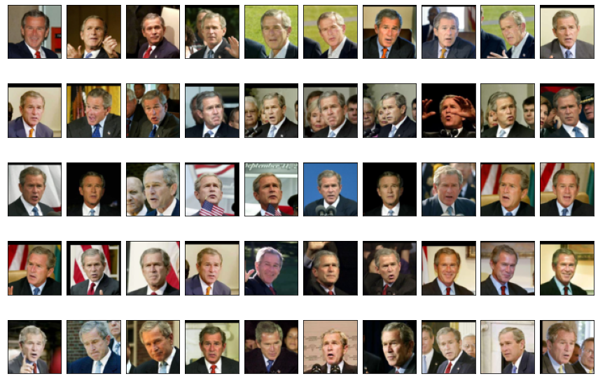

```python
_ = plot.dataset_first_n(ds_gwb, 50, figsize=(15,10), nrows=5)
print(f'Found {len(ds_gwb)} images in dataset folder.')
```

```python
x0, y0 = ds_gwb[0]
x0 = x0.unsqueeze(0).to(device)
print(x0.shape)

test.assertSequenceEqual(x0.shape, (1, 3, im_size, im_size))
```

```
torch.Size([1, 3, 64, 64])
```

## The Variational Autoencoder

An autoencoder is a model which learns a representation of data in an **unsupervised** fashion (i.e without any labels). Recall it's general form from the lecture:

[figure not shown]

An autoencoder maps an instance $\bb{x}$ to a **latent-space** representation $\bb{z}$. It has an encoder part, $\Phi_{\bb{\alpha}}(\bb{x})$ (a model with parameters $\bb{\alpha}$) and a decoder part, $\Psi_{\bb{\beta}}(\bb{z})$ (a model with parameters $\bb{\beta}$).

While autoencoders can learn useful representations, generally it's hard to use them as generative models because there's no distribution we can sample from in the latent space. In other words, we have no way to choose a point $\bb{z}$ in the latent space such that $\Psi(\bb{z})$ will end up on the data manifold in the instance space.

[figure not shown]

The variational autoencoder (VAE), first proposed by [Kingma and Welling](https://arxiv.org/pdf/1312.6114.pdf), addresses this issue by taking a probabilistic perspective. Briefly, a VAE model can be described as follows.

We define, in Baysean terminology,

- The **prior** distribution $p(\bb{Z})$ on points in the latent space.
- The **posterior** distribution of points in the latent spaces given a specific instance: $p(\bb{Z}|\bb{X})$.
- The **likelihood** distribution of a sample $\bb{X}$ given a latent-space representation: $p(\bb{X}|\bb{Z})$.
- The **evidence** distribution $p(\bb{X})$ which is the distribution of the instance space due to the generative process.

To create our variational **decoder** we'll further specify:

- A parametric likelihood distribution, $p _{\bb{\beta}}(\bb{X} | \bb{Z}=\bb{z}) = \mathcal{N}( \Psi _{\bb{\beta}}(\bb{z}) , \sigma^2 \bb{I} )$. The interpretation is that given a latent $\bb{z}$, we map it to a point normally distributed around the point calculated by our decoder neural network. Note that here $\sigma^2$ is a hyperparameter while $\vec{\beta}$ represents the network parameters.
- A fixed latent-space prior distribution of $p(\bb{Z}) = \mathcal{N}(\bb{0},\bb{I})$.

This setting allows us to generate a new instance $\bb{x}$ by sampling $\bb{z}$ from the multivariate normal distribution, obtaining the instance-space mean $\Psi _{\bb{\beta}}(\bb{z})$ using our decoder network, and then sampling $\bb{x}$ from $\mathcal{N}( \Psi _{\bb{\beta}}(\bb{z}) , \sigma^2 \bb{I} )$.

Our variational **encoder** will approximate the posterior with a parametric distribution $q _{\bb{\alpha}}(\bb{Z} | \bb{x}) = \mathcal{N}( \bb{\mu} _{\bb{\alpha}}(\bb{x}), \mathrm{diag}\{ \bb{\sigma}^2_{\bb{\alpha}}(\bb{x}) \} )$. The interpretation is that our encoder model, $\Phi_{\vec{\alpha}}(\bb{x})$, calculates the mean and variance of the posterior distribution, and samples $\bb{z}$ based on them. An important nuance here is that our network can't contain any stochastic elements that depend on the model parameters, otherwise we won't be able to back-propagate to those parameters. So sampling $\bb{z}$ from $\mathcal{N}( \bb{\mu} _{\bb{\alpha}}(\bb{x}), \mathrm{diag}\{ \bb{\sigma}^2_{\bb{\alpha}}(\bb{x}) \} )$ is not an option. The solution is to use what's known as the **reparametrization trick**: sample from an isotropic Gaussian, i.e. $\bb{u}\sim\mathcal{N}(\bb{0},\bb{I})$ (which doesn't depend on trainable parameters), and calculate the latent representation as $\bb{z} = \bb{\mu} _{\bb{\alpha}}(\bb{x}) + \bb{u}\odot\bb{\sigma}_{\bb{\alpha}}(\bb{x})$.

To train a VAE model, we maximize the evidence distribution, $p(\bb{X})$ (see question below). The **VAE loss** can therefore be stated as minimizing $\mathcal{L} = -\mathbb{E}_{\bb{x}} \log p(\bb{X})$. Although this expectation is intractable, we can obtain a lower-bound for $p(\bb{X})$ (the evidence lower bound, "ELBO", shown in the lecture):

$$ \log p(\bb{X}) \ge \mathbb{E} _{\bb{z} \sim q _{\bb{\alpha}} }\left[ \log p _{\bb{\beta}}(\bb{X} | \bb{z}) \right] - \mathcal{D} _{\mathrm{KL}}\left(q _{\bb{\alpha}}(\bb{Z} | \bb{X})\,\left\|\, p(\bb{Z} )\right.\right) $$

where $ \mathcal{D} _{\mathrm{KL}}(q\left\|\right.p) = \mathbb{E}_{\bb{z}\sim q}\left[ \log \frac{q(\bb{Z})}{p(\bb{Z})} \right] $ is the Kullback-Liebler divergence, which can be interpreted as the information gained by using the posterior $q(\bb{Z|X})$ instead of the prior distribution $p(\bb{Z})$.

By remembering that the likelihood is a Gaussian distribution with a diagonal covariance and by applying the reparametrization trick, we can write the above as

$$ \mathcal{L}(\vec{\alpha},\vec{\beta}) = \mathbb{E} _{\bb{x}} \left[ \mathbb{E} _{\bb{z} \sim q _{\bb{\alpha}} } \left[ \frac{1}{2\sigma^2}\left\| \bb{x}- \Psi _{\bb{\beta}}\left( \bb{\mu} _{\bb{\alpha}}(\bb{x}) + \bb{\Sigma}^{\frac{1}{2}} _{\bb{\alpha}}(\bb{x}) \bb{u} \right) \right\| _2^2 \right] + \mathcal{D} _{\mathrm{KL}}\left(q _{\bb{\alpha}}(\bb{Z} | \bb{x})\,\left\|\, p(\bb{Z} )\right.\right) \right]. $$

### Model Implementation

Obviously our model will have two parts, an encoder and a decoder. Since we're working with images, we'll implement both as deep **convolutional** networks, where the decoder is a "mirror image" of the encoder implemented with adjoint (AKA transposed) convolutions. Between the encoder CNN and the decoder CNN we'll implement the sampling from the parametric posterior approximator $q_{\bb{\alpha}}(\bb{Z}|\bb{x})$ to make it a VAE model and not just a regular autoencoder (of course, this is not yet enough to create a VAE, since we also need a special loss function which we'll get to later).

First let's implement just the CNN part of the Encoder network (this is not the full $\Phi_{\vec{\alpha}}(\bb{x})$ yet). As usual, it should take an input image and map to a activation volume of a specified depth. We'll consider this volume as the features we extract from the input image. Later we'll use these to create the latent space representation of the input.

**TODO**: Implement the `EncoderCNN` class in the `hw4/autoencoder.py` module. Implement any CNN architecture you like. If you need "architecture inspiration" you can see e.g. [this](https://arxiv.org/pdf/1512.09300.pdf) or [this](https://arxiv.org/pdf/1511.06434.pdf) paper.

```python
import hw4.autoencoder as autoencoder

in_channels = 3
out_channels = 1024
encoder_cnn = autoencoder.EncoderCNN(in_channels, out_channels).to(device)
print(encoder_cnn)

h = encoder_cnn(x0)
print(h.shape)

test.assertEqual(h.dim(), 4)
test.assertSequenceEqual(h.shape[0:2], (1, out_channels))
```

```
EncoderCNN(
  (cnn): Sequential(
    (0): Conv2d(3, 64, kernel_size=(5, 5), stride=(2, 2), padding=(2, 2))
    (1): MaxPool2d(kernel_size=3, stride=1, padding=1, dilation=1, ceil_mode=False)
    (2): BatchNorm2d(64, eps=1e-06, momentum=0.9, affine=True, track_running_stats=True)
    (3): ReLU()
    (4): Dropout2d(p=0.3, inplace=False)
    (5): Conv2d(64, 128, kernel_size=(5, 5), stride=(2, 2), padding=(2, 2))
    (6): MaxPool2d(kernel_size=3, stride=1, padding=1, dilation=1, ceil_mode=False)
    (7): BatchNorm2d(128, eps=1e-06, momentum=0.9, affine=True, track_running_stats=True)
    (8): ReLU()
    (9): Dropout2d(p=0.3, inplace=False)
    (10): Conv2d(128, 256, kernel_size=(5, 5), stride=(2, 2), padding=(2, 2))
    (11): MaxPool2d(kernel_size=3, stride=1, padding=1, dilation=1, ceil_mode=False)
    (12): BatchNorm2d(256, eps=1e-06, momentum=0.9, affine=True, track_running_stats=True)
    (13): ReLU()
    (14): Dropout2d(p=0.3, inplace=False)
    (15): Conv2d(256, 1024, kernel_size=(5, 5), stride=(1, 1), padding=(2, 2))
  )
)
torch.Size([1, 1024, 8, 8])
```

Now let's implement the CNN part of the Decoder. Again this is not yet the full $\Psi _{\bb{\beta}}(\bb{z})$. It should take an activation volume produced by your `EncoderCNN` and output an image of the same dimensions as the Encoder's input was. This can be a CNN which is like a "mirror image" of the the Encoder. For example, replace convolutions with transposed convolutions, downsampling with up-sampling etc. Consult the documentation of [ConvTranspose2D](https://pytorch.org/docs/0.4.1/nn.html#convtranspose2d) to figure out how to reverse your convolutional layers in terms of input and output dimensions. Note that the decoder doesn't have to be exactly the opposite of the encoder and you can experiment with using a different architecture.

**TODO**: Implement the `DecoderCNN` class in the `hw4/autoencoder.py` module.

```python
decoder_cnn = autoencoder.DecoderCNN(in_channels=out_channels, out_channels=in_channels).to(device)
print(decoder_cnn)
x0r = decoder_cnn(h)
print(x0r.shape)

test.assertEqual(x0.shape, x0r.shape)

# Should look like colored noise
T.functional.to_pil_image(x0r[0].cpu().detach())
```

[output not shown]

```
DecoderCNN(
  (cnn): Sequential(
    (0): ConvTranspose2d(1024, 256, kernel_size=(5, 5), stride=(1, 1), padding=(2, 2))
    (1): BatchNorm2d(256, eps=1e-06, momentum=0.9, affine=True, track_running_stats=True)
    (2): ReLU()
    (3): ConvTranspose2d(256, 128, kernel_size=(5, 5), stride=(2, 2), padding=(2, 2), output_padding=(1, 1))
    (4): Dropout2d(p=0.3, inplace=False)
    (5): BatchNorm2d(128, eps=1e-06, momentum=0.9, affine=True, track_running_stats=True)
    (6): ReLU()
    (7): ConvTranspose2d(128, 64, kernel_size=(5, 5), stride=(2, 2), padding=(2, 2), output_padding=(1, 1))
    (8): Dropout2d(p=0.3, inplace=False)
    (9): BatchNorm2d(64, eps=1e-06, momentum=0.9, affine=True, track_running_stats=True)
    (10): ReLU()
    (11): ConvTranspose2d(64, 3, kernel_size=(5, 5), stride=(2, 2), padding=(2, 2), output_padding=(1, 1))
    (12): Dropout2d(p=0.3, inplace=False)
  )
)
torch.Size([1, 3, 64, 64])
```

Let's now implement the full VAE Encoder, $\Phi_{\vec{\alpha}}(\vec{x})$. It will work as follows:

1. Produce a feature vector $\vec{h}$ from the input image $\vec{x}$.
2. Use two affine transforms to convert the features into the mean and log-variance of the posterior, i.e. $$ \begin{align}

   ```
    \bb{\mu} _{\bb{\alpha}}(\bb{x}) &= \vec{h}\mattr{W}_{\mathrm{h\mu}} + \vec{b}_{\mathrm{h\mu}} \\
    \log\left(\bb{\sigma}^2_{\bb{\alpha}}(\bb{x})\right) &= \vec{h}\mattr{W}_{\mathrm{h\sigma^2}} + \vec{b}_{\mathrm{h\sigma^2}}
   ```

   \end{align} $$
3. Use the **reparametrization trick** to create the latent representation $\vec{z}$.

Notice that we model the **log** of the variance, not the actual variance. The above formulation is proposed in appendix C of the [VAE paper](https://arxiv.org/pdf/1312.6114.pdf).

**TODO**: Implement the `encode()` method in the `VAE` class within the `hw4/autoencoder.py` module. You'll also need to define your parameters in `__init__()`.

```python
z_dim = 2
vae = autoencoder.VAE(encoder_cnn, decoder_cnn, x0[0].size(), z_dim).to(device)
print(vae)

z, mu, log_sigma2 = vae.encode(x0)

test.assertSequenceEqual(z.shape, (1, z_dim))
test.assertTrue(z.shape == mu.shape == log_sigma2.shape)

print(f'mu(x0)={list(*mu.detach().cpu().numpy())}, sigma2(x0)={list(*torch.exp(log_sigma2).detach().cpu().numpy())}')
```

```
VAE(
  (features_encoder): EncoderCNN(
    (cnn): Sequential(
      (0): Conv2d(3, 64, kernel_size=(5, 5), stride=(2, 2), padding=(2, 2))
      (1): MaxPool2d(kernel_size=3, stride=1, padding=1, dilation=1, ceil_mode=False)
      (2): BatchNorm2d(64, eps=1e-06, momentum=0.9, affine=True, track_running_stats=True)
      (3): ReLU()
      (4): Dropout2d(p=0.3, inplace=False)
      (5): Conv2d(64, 128, kernel_size=(5, 5), stride=(2, 2), padding=(2, 2))
      (6): MaxPool2d(kernel_size=3, stride=1, padding=1, dilation=1, ceil_mode=False)
      (7): BatchNorm2d(128, eps=1e-06, momentum=0.9, affine=True, track_running_stats=True)
      (8): ReLU()
      (9): Dropout2d(p=0.3, inplace=False)
      (10): Conv2d(128, 256, kernel_size=(5, 5), stride=(2, 2), padding=(2, 2))
      (11): MaxPool2d(kernel_size=3, stride=1, padding=1, dilation=1, ceil_mode=False)
      (12): BatchNorm2d(256, eps=1e-06, momentum=0.9, affine=True, track_running_stats=True)
      (13): ReLU()
      (14): Dropout2d(p=0.3, inplace=False)
      (15): Conv2d(256, 1024, kernel_size=(5, 5), stride=(1, 1), padding=(2, 2))
    )
  )
  (features_decoder): DecoderCNN(
    (cnn): Sequential(
      (0): ConvTranspose2d(1024, 256, kernel_size=(5, 5), stride=(1, 1), padding=(2, 2))
      (1): BatchNorm2d(256, eps=1e-06, momentum=0.9, affine=True, track_running_stats=True)
      (2): ReLU()
      (3): ConvTranspose2d(256, 128, kernel_size=(5, 5), stride=(2, 2), padding=(2, 2), output_padding=(1, 1))
      (4): Dropout2d(p=0.3, inplace=False)
      (5): BatchNorm2d(128, eps=1e-06, momentum=0.9, affine=True, track_running_stats=True)
      (6): ReLU()
      (7): ConvTranspose2d(128, 64, kernel_size=(5, 5), stride=(2, 2), padding=(2, 2), output_padding=(1, 1))
      (8): Dropout2d(p=0.3, inplace=False)
      (9): BatchNorm2d(64, eps=1e-06, momentum=0.9, affine=True, track_running_stats=True)
      (10): ReLU()
      (11): ConvTranspose2d(64, 3, kernel_size=(5, 5), stride=(2, 2), padding=(2, 2), output_padding=(1, 1))
      (12): Dropout2d(p=0.3, inplace=False)
    )
  )
  (gen_mu): Linear(in_features=65536, out_features=2, bias=True)
  (gen_logvar): Linear(in_features=65536, out_features=2, bias=True)
  (z_to_h): Linear(in_features=2, out_features=65536, bias=True)
)
mu(x0)=[-0.20894682, -0.13209724], sigma2(x0)=[1.1836163, 0.8043333]
```

Let's sample some 2d latent representations for an input image `x0` and visualize them.

```
sampled mu tensor([-0.0718, -0.0529])
sampled sigma2 tensor([0.9360, 0.7562])
```

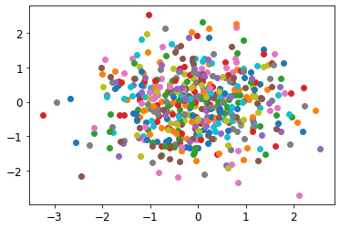

```python
# Sample from q(Z|x)
N = 500
Z = torch.zeros(N, z_dim)
_, ax = plt.subplots()
with torch.no_grad():
    for i in range(N):
        Z[i], _, _ = vae.encode(x0)
        ax.scatter(*Z[i].cpu().numpy())

# Should be close to the mu/sigma in the previous block above
print('sampled mu', torch.mean(Z, dim=0))
print('sampled sigma2', torch.var(Z, dim=0))
```

Let's now implement the full VAE Decoder, $\Psi _{\bb{\beta}}(\bb{z})$. It will work as follows:

1. Produce a feature vector $\tilde{\vec{h}}$ from the latent vector $\vec{z}$ using an affine transform.
2. Reconstruct an image $\tilde{\vec{x}}$ from $\tilde{\vec{h}}$ using the decoder CNN.

**TODO**: Implement the `decode()` method in the `VAE` class within the `hw4/autoencoder.py` module. You'll also need to define your parameters in `__init__()`. You may need to also re-run the block above after you implement this.

```python
x0r = vae.decode(z)

test.assertSequenceEqual(x0r.shape, x0.shape)
```

Our model's `forward()` function will simply return `decode(encode(x))` as well as the calculated mean and log-variance of the posterior.

```python
x0r, mu, log_sigma2 = vae(x0)

test.assertSequenceEqual(x0r.shape, x0.shape)
test.assertSequenceEqual(mu.shape, (1, z_dim))
test.assertSequenceEqual(log_sigma2.shape, (1, z_dim))
T.functional.to_pil_image(x0r[0].detach().cpu())
```

[output not shown]

### Loss Implementation

In practice, since we're using SGD, we'll drop the expectation over $\bb{X}$ and instead sample an instance from the training set and compute a point-wise loss. Similarly, we'll drop the expectation over $\bb{Z}$ by sampling from $q_{\vec{\alpha}}(\bb{Z}|\bb{x})$. Additionally, because the KL divergence is between two Gaussian distributions, there is a closed-form expression for it. These points bring us to the following point-wise loss:

$$ \ell(\vec{\alpha},\vec{\beta};\bb{x}) = \frac{1}{\sigma^2 d_x} \left\| \bb{x}- \Psi _{\bb{\beta}}\left( \bb{\mu} _{\bb{\alpha}}(\bb{x}) + \bb{\Sigma}^{\frac{1}{2}} _{\bb{\alpha}}(\bb{x}) \bb{u} \right) \right\| _2^2 + \mathrm{tr}\,\bb{\Sigma} _{\bb{\alpha}}(\bb{x}) + \|\bb{\mu} _{\bb{\alpha}}(\bb{x})\|^2 _2 - d_z - \log\det \bb{\Sigma} _{\bb{\alpha}}(\bb{x}), $$

where $d_z$ is the dimension of the latent space, $d_x$ is the dimension of the input and $\bb{u}\sim\mathcal{N}(\bb{0},\bb{I})$. This pointwise loss is the quantity that we'll compute and minimize with gradient descent. The first term corresponds to the data-reconstruction loss, while the second term corresponds to the KL-divergence loss. Note that the scaling by $d_x$ is not derived from the original loss formula and was added directly to the pointwise loss just to normalize the data term.

**TODO**: Implement the `vae_loss()` function in the `hw4/autoencoder.py` module.

```python
from hw4.autoencoder import vae_loss
torch.manual_seed(42)

def test_vae_loss():
    # Test data
    N, C, H, W = 10, 3, 64, 64
    z_dim = 32
    x  = torch.randn(N, C, H, W)*2 - 1
    xr = torch.randn(N, C, H, W)*2 - 1
    z_mu = torch.randn(N, z_dim)
    z_log_sigma2 = torch.randn(N, z_dim)
    x_sigma2 = 0.9

    loss, _, _ = vae_loss(x, xr, z_mu, z_log_sigma2, x_sigma2)

    test.assertAlmostEqual(loss.item(), 58.3234367, delta=1e-3)
    return loss

test_vae_loss()
```

```
tensor(58.3234)
```

### Sampling

The main advantage of a VAE is that it can by used as a generative model by sampling the latent space, since we optimize for a isotropic Gaussian prior $p(\bb{Z})$ in the loss function. Let's now implement this so that we can visualize how our model is doing when we train.

**TODO**: Implement the `sample()` method in the `VAE` class within the `hw4/autoencoder.py` module.

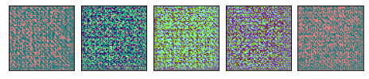

```python
samples = vae.sample(5)
_ = plot.tensors_as_images(samples)
```

### Training

Time to train!

**TODO**:

1. Implement the `VAETrainer` class in the `hw4/training.py` module. Make sure to implement the `checkpoints` feature of the `Trainer` class if you haven't done so already in Part 1.
2. Tweak the hyperparameters in the `part2_vae_hyperparams()` function within the `hw4/answers.py` module.

```python
import torch.optim as optim
from torch.utils.data import random_split
from torch.utils.data import DataLoader
from torch.nn import DataParallel
from hw4.training import VAETrainer
from hw4.answers import part2_vae_hyperparams

torch.manual_seed(42)

# Hyperparams
hp = part2_vae_hyperparams()
batch_size = hp['batch_size']
h_dim = hp['h_dim']
z_dim = hp['z_dim']
x_sigma2 = hp['x_sigma2']
learn_rate = hp['learn_rate']
betas = hp['betas']

# Data
split_lengths = [int(len(ds_gwb)*0.9), int(len(ds_gwb)*0.1)]
ds_train, ds_test = random_split(ds_gwb, split_lengths)
dl_train = DataLoader(ds_train, batch_size, shuffle=True)
dl_test  = DataLoader(ds_test,  batch_size, shuffle=True)
im_size = ds_train[0][0].shape

# Model
encoder = autoencoder.EncoderCNN(in_channels=im_size[0], out_channels=h_dim)
decoder = autoencoder.DecoderCNN(in_channels=h_dim, out_channels=im_size[0])
vae = autoencoder.VAE(encoder, decoder, im_size, z_dim)
vae_dp = DataParallel(vae).to(device)

# Optimizer
optimizer = optim.Adam(vae.parameters(), lr=learn_rate, betas=betas)

# Loss
def loss_fn(x, xr, z_mu, z_log_sigma2):
    return autoencoder.vae_loss(x, xr, z_mu, z_log_sigma2, x_sigma2)

# Trainer
trainer = VAETrainer(vae_dp, loss_fn, optimizer, device)
checkpoint_file = 'checkpoints/vae'
checkpoint_file_final = f'{checkpoint_file}_final'
if os.path.isfile(f'{checkpoint_file}.pt'):
    os.remove(f'{checkpoint_file}.pt')

# Show model and hypers
print(vae)
print(hp)
```

```
VAE(
  (features_encoder): EncoderCNN(
    (cnn): Sequential(
      (0): Conv2d(3, 64, kernel_size=(5, 5), stride=(2, 2), padding=(2, 2))
      (1): MaxPool2d(kernel_size=3, stride=1, padding=1, dilation=1, ceil_mode=False)
      (2): BatchNorm2d(64, eps=1e-06, momentum=0.9, affine=True, track_running_stats=True)
      (3): ReLU()
      (4): Dropout2d(p=0.3, inplace=False)
      (5): Conv2d(64, 128, kernel_size=(5, 5), stride=(2, 2), padding=(2, 2))
      (6): MaxPool2d(kernel_size=3, stride=1, padding=1, dilation=1, ceil_mode=False)
      (7): BatchNorm2d(128, eps=1e-06, momentum=0.9, affine=True, track_running_stats=True)
      (8): ReLU()
      (9): Dropout2d(p=0.3, inplace=False)
      (10): Conv2d(128, 256, kernel_size=(5, 5), stride=(2, 2), padding=(2, 2))
      (11): MaxPool2d(kernel_size=3, stride=1, padding=1, dilation=1, ceil_mode=False)
      (12): BatchNorm2d(256, eps=1e-06, momentum=0.9, affine=True, track_running_stats=True)
      (13): ReLU()
      (14): Dropout2d(p=0.3, inplace=False)
      (15): Conv2d(256, 128, kernel_size=(5, 5), stride=(1, 1), padding=(2, 2))
    )
  )
  (features_decoder): DecoderCNN(
    (cnn): Sequential(
      (0): ConvTranspose2d(128, 256, kernel_size=(5, 5), stride=(1, 1), padding=(2, 2))
      (1): BatchNorm2d(256, eps=1e-06, momentum=0.9, affine=True, track_running_stats=True)
      (2): ReLU()
      (3): ConvTranspose2d(256, 128, kernel_size=(5, 5), stride=(2, 2), padding=(2, 2), output_padding=(1, 1))
      (4): Dropout2d(p=0.3, inplace=False)
      (5): BatchNorm2d(128, eps=1e-06, momentum=0.9, affine=True, track_running_stats=True)
      (6): ReLU()
      (7): ConvTranspose2d(128, 64, kernel_size=(5, 5), stride=(2, 2), padding=(2, 2), output_padding=(1, 1))
      (8): Dropout2d(p=0.3, inplace=False)
      (9): BatchNorm2d(64, eps=1e-06, momentum=0.9, affine=True, track_running_stats=True)
      (10): ReLU()
      (11): ConvTranspose2d(64, 3, kernel_size=(5, 5), stride=(2, 2), padding=(2, 2), output_padding=(1, 1))
      (12): Dropout2d(p=0.3, inplace=False)
    )
  )
  (gen_mu): Linear(in_features=8192, out_features=256, bias=True)
  (gen_logvar): Linear(in_features=8192, out_features=256, bias=True)
  (z_to_h): Linear(in_features=256, out_features=8192, bias=True)
)
{'batch_size': 4, 'h_dim': 128, 'z_dim': 256, 'x_sigma2': 0.1, 'learn_rate': 0.0005, 'betas': (0.9, 0.999)}
```

**TODO**:

1. Run the following block to train. It will sample some images from your model every few epochs so you can see the progress.
2. When you're satisfied with your results, rename the checkpoints file by adding `_final`. When you run the `main.py` script to generate your submission, the final checkpoints file will be loaded instead of running training. Note that your final submission zip will not include the `checkpoints/` folder. This is OK.

The images you get should be colorful, with different backgrounds and poses.

```
*** Loading final checkpoint file checkpoints/vae_final instead of training
*** Images Generated from best model:
```

```
C:\Users\alon2\Google Drive\Studies 2\Year 2\Semester A\Deep Learning\HW_final\hw4\cs3600\plot.py:45: RuntimeWarning: invalid value encountered in true_divide
  image = (image - min) / (max - min)
```

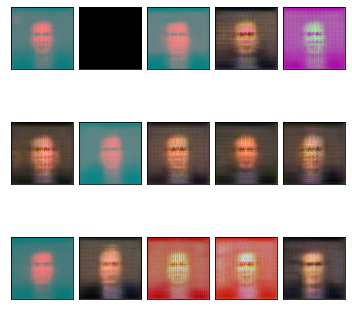

```python
import IPython.display

def post_epoch_fn(epoch, train_result, test_result, verbose):
    # Plot some samples if this is a verbose epoch
    if verbose:
        samples = vae.sample(n=5)
        fig, _ = plot.tensors_as_images(samples, figsize=(6,2))
        IPython.display.display(fig)
        plt.close(fig)

if os.path.isfile(f'{checkpoint_file_final}.pt'):
    print(f'*** Loading final checkpoint file {checkpoint_file_final} instead of training')
    checkpoint_file = checkpoint_file_final
else:
    res = trainer.fit(dl_train, dl_test,
                      num_epochs=200, early_stopping=20, print_every=10,
                      checkpoints=checkpoint_file,
                      post_epoch_fn=post_epoch_fn)

# Plot images from best model
saved_state = torch.load(f'{checkpoint_file}.pt', map_location=device)
vae_dp.load_state_dict(saved_state['model_state'])
print('*** Images Generated from best model:')
fig, _ = plot.tensors_as_images(vae_dp.module.sample(n=15), nrows=3, figsize=(6,6))
```

## Questions

**TODO** Answer the following questions. Write your answers in the appropriate variables in the module `hw4/answers.py`.

```python
from cs3600.answers import display_answer
import hw4.answers
```

### Question 1

What does the $\sigma^2$ hyperparameter (`x_sigma2` in the code) do? Explain the effect of low and high values.

```python
display_answer(hw4.answers.part2_q1)
```

**Your answer:** The $\sigma^2$ controls the variance of the normal distribution of the latent space. By increasing it's value, we will get a wider distribution what will cause the sampled instances by the VAE to vary fromeach other and from the dataset. By decreaing it's value, we will get a narrower distribution which is closer to the training data. Therefore, this parameter should be used smartly to avoid to much variance from the training set on one hand, but to avoid overfitting on the other hand.

### Question 2

1. Explain the purpose of both parts of the VAE loss term - reconstruction loss and KL divergence loss.
2. How is the latent-space distribution affected by the KL loss term?
3. What's the benefit of this effect?

```python
display_answer(hw4.answers.part2_q2)
```

**Your answer:** 1. The reconstruction loss- it's purpose is to cause the generated data as close to the input data. It does that under the L2 norm, by minimizing it's value. The KL loss- It's purpose is to try and make the encoder aproximate the posterior distribution correctly. This is in order to generate data closer to real data.

2.

3. The benifit of using KL loss is to control the variance of the latent space distribution. The need to control the variance was explained in q1 above.

### Question 3

In the formulation of the VAE loss, why do we start by maximizing the evidence distribution, $p(\bb{X})$?

```python
display_answer(hw4.answers.part2_q3)
```

**Your answer:** Basically we don't know the evidence distribuiton which is used to generate new data points. In order to get close to it, we try to estimate by maximizing it and trying to get it close as possible to the real distribution.

### Question 4

In the VAE encoder, why do we model the **log** of the latent-space variance corresponding to an input, $\bb{\sigma}^2_{\bb{\alpha}}$, instead of directly modelling this variance?

```python
display_answer(hw4.answers.part2_q4)
```

**Your answer:** We model the log of the latent space variace instead of directly model the variance itself for numeric stability. Usually, the variance values are positive close to zero numbers. We use the log of their values to spread them across wider region of numbers (log can get values from -infinity to infinity). Also, the log function is differentiable all over it's range, so calculating it's derivitive during backprop is easy.

$$ \newcommand{\mat}[1]{\boldsymbol {#1}} \newcommand{\mattr}[1]{\boldsymbol {#1}^\top} \newcommand{\matinv}[1]{\boldsymbol {#1}^{-1}} \newcommand{\vec}[1]{\boldsymbol {#1}} \newcommand{\vectr}[1]{\boldsymbol {#1}^\top} \newcommand{\rvar}[1]{\mathrm {#1}} \newcommand{\rvec}[1]{\boldsymbol{\mathrm{#1}}} \newcommand{\diag}{\mathop{\mathrm {diag}}} \newcommand{\set}[1]{\mathbb {#1}} \newcommand{\norm}[1]{\left\lVert#1\right\rVert} \newcommand{\pderiv}[2]{\frac{\partial #1}{\partial #2}} \newcommand{\bm}[1]{{\bf #1}} \newcommand{\bb}[1]{\bm{\mathrm{#1}}} $$

# Part 3: Generative Adversarial Networks

In this part we will implement and train a generative adversarial network and apply it to the task of image generation.

```python
import unittest
import os
import sys
import pathlib
import urllib
import shutil
import re
import zipfile

import numpy as np
import torch
import matplotlib.pyplot as plt

%load_ext autoreload
%autoreload 2

test = unittest.TestCase()
plt.rcParams.update({'font.size': 12})
device = torch.device('cuda' if torch.cuda.is_available() else 'cpu')
print('Using device:', device)
```

```
Using device: cpu
```

### Obtaining the dataset

But again, you can use a custom dataset, by editing the `PART3_CUSTOM_DATA_URL` variable in `hw4/answers.py`.

```python
import cs3600.plot as plot
import cs3600.download
from hw4.answers import PART3_CUSTOM_DATA_URL as CUSTOM_DATA_URL

DATA_DIR = pathlib.Path.home().joinpath('.pytorch-datasets')
if CUSTOM_DATA_URL is None:
    DATA_URL = 'http://vis-www.cs.umass.edu/lfw/lfw-bush.zip'
else:
    DATA_URL = CUSTOM_DATA_URL

_, dataset_dir = cs3600.download.download_data(out_path=DATA_DIR, url=DATA_URL, extract=True, force=False)
```

```
File C:\Users\alon2\.pytorch-datasets\lfw-bush.zip exists, skipping download.
Extracting C:\Users\alon2\.pytorch-datasets\lfw-bush.zip...
Extracted 531 to C:\Users\alon2\.pytorch-datasets\lfw/George_W_Bush
```

Create a `Dataset` object that will load the extraced images:

```python
import torchvision.transforms as T
from torchvision.datasets import ImageFolder

im_size = 64
tf = T.Compose([
    # Resize to constant spatial dimensions
    T.Resize((im_size, im_size)),
    # PIL.Image -> torch.Tensor
    T.ToTensor(),
    # Dynamic range [0,1] -> [-1, 1]
    T.Normalize(mean=(.5,.5,.5), std=(.5,.5,.5)),
])

ds_gwb = ImageFolder(os.path.dirname(dataset_dir), tf)
```

OK, let's see what we got. You can run the following block multiple times to display a random subset of images from the dataset.

```
Found 530 images in dataset folder.
```

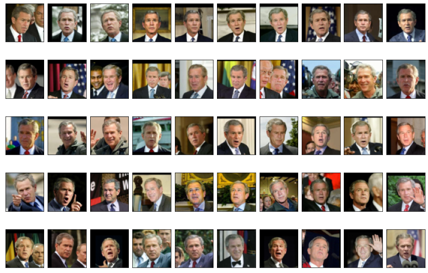

```python
_ = plot.dataset_first_n(ds_gwb, 50, figsize=(15,10), nrows=5)
print(f'Found {len(ds_gwb)} images in dataset folder.')
```

```python
x0, y0 = ds_gwb[0]
x0 = x0.unsqueeze(0).to(device)
print(x0.shape)

test.assertSequenceEqual(x0.shape, (1, 3, im_size, im_size))
```

```
torch.Size([1, 3, 64, 64])
```

## Generative Adversarial Nets (GANs)

GANs, first proposed in a [paper](https://arxiv.org/pdf/1406.2661.pdf) by Ian Goodfellow in 2014 are today arguably the most popular type of generative model. GANs are currently producing state of the art results in generative tasks over many different domains.

In a GAN model, two different neural networks compete against each other: A **generator** and a **discriminator**.

- The Generator, which we'll denote as $\Psi _{\bb{\gamma}} : \mathcal{U} \rightarrow \mathcal{X}$, maps a latent-space variable $\bb{u}\sim\mathcal{N}(\bb{0},\bb{I})$ to an instance-space variable $\bb{x}$ (e.g. an image). Thus a parametric evidence distribution $p_{\bb{\gamma}}(\bb{X})$ is generated, which we typically would like to be as close as possible to the real evidence distribution, $p(\bb{X})$.
- The Discriminator, $\Delta _{\bb{\delta}} : \mathcal{X} \rightarrow [0,1]$, is a network which, given an instance-space variable $\bb{x}$, returns the probability that $\bb{x}$ is real, i.e. that $\bb{x}$ was sampled from $p(\bb{X})$ and not $p_{\bb{\gamma}}(\bb{X})$.

[figure not shown]

### Training GANs

The generator is trained to generate "fake" instances which will maximally fool the discriminator into returning that they're real. Mathematically, the generator's parameters $\bb{\gamma}$ should be chosen such as to **maximize** the expression $$ \mathbb{E} _{\bb{z} \sim p(\bb{Z}) } \log (\Delta _{\bb{\delta}}(\Psi _{\bb{\gamma}} (\bb{z}) )). $$

The discriminator is trained to classify between real images, coming from the training set, and fake images generated by the generator. Mathematically, the discriminator's parameters $\bb{\delta}$ should be chosen such as to **maximize** the expression $$ \mathbb{E} _{\bb{x} \sim p(\bb{X}) } \log \Delta _{\bb{\delta}}(\bb{x}) \, + \, \mathbb{E} _{\bb{z} \sim p(\bb{Z}) } \log (1-\Delta _{\bb{\delta}}(\Psi _{\bb{\gamma}} (\bb{z}) )). $$

These two competing objectives can thus be expressed as the following min-max optimization: $$ \min _{\bb{\gamma}} \max _{\bb{\delta}} \, \mathbb{E} _{\bb{x} \sim p(\bb{X}) } \log \Delta _{\bb{\delta}}(\bb{x}) \, + \, \mathbb{E} _{\bb{z} \sim p(\bb{Z}) } \log (1-\Delta _{\bb{\delta}}(\Psi _{\bb{\gamma}} (\bb{z}) )). $$

A key insight into GANs is that we can interpret the above maximum as the *loss* with respect to $\bb{\gamma}$:

$$ L({\bb{\gamma}}) = \max _{\bb{\delta}} \, \mathbb{E} _{\bb{x} \sim p(\bb{X}) } \log \Delta _{\bb{\delta}}(\bb{x}) \, + \, \mathbb{E} _{\bb{z} \sim p(\bb{Z}) } \log (1-\Delta _{\bb{\delta}}(\Psi _{\bb{\gamma}} (\bb{z}) )). $$

This means that the generator's loss function trains together with the generator itself in an adversarial manner. In contrast, when training our VAE we used a fixed L2 norm as a data loss term.

### Model Implementation

We'll now implement a Deep Convolutional GAN (DCGAN) model. See the DCGAN [paper](https://arxiv.org/pdf/1511.06434.pdf) for architecture ideas and tips for training.

**TODO**: Implement the `Discriminator` class in the `hw4/gan.py` module. If you wish you can reuse the `EncoderCNN` class from the VAE model as the first part of the Discriminator.

```python
import hw4.gan as gan

dsc = gan.Discriminator(in_size=x0[0].shape).to(device)
print(dsc)

d0 = dsc(x0)
print(d0.shape)

test.assertSequenceEqual(d0.shape, (1,1))
```

```
Discriminator(
  (cnn): EncoderCNN(
    (cnn): Sequential(
      (0): Conv2d(3, 64, kernel_size=(5, 5), stride=(2, 2), padding=(2, 2))
      (1): MaxPool2d(kernel_size=3, stride=1, padding=1, dilation=1, ceil_mode=False)
      (2): BatchNorm2d(64, eps=1e-06, momentum=0.9, affine=True, track_running_stats=True)
      (3): ReLU()
      (4): Dropout2d(p=0.3, inplace=False)
      (5): Conv2d(64, 128, kernel_size=(5, 5), stride=(2, 2), padding=(2, 2))
      (6): MaxPool2d(kernel_size=3, stride=1, padding=1, dilation=1, ceil_mode=False)
      (7): BatchNorm2d(128, eps=1e-06, momentum=0.9, affine=True, track_running_stats=True)
      (8): ReLU()
      (9): Dropout2d(p=0.3, inplace=False)
      (10): Conv2d(128, 256, kernel_size=(5, 5), stride=(2, 2), padding=(2, 2))
      (11): MaxPool2d(kernel_size=3, stride=1, padding=1, dilation=1, ceil_mode=False)
      (12): BatchNorm2d(256, eps=1e-06, momentum=0.9, affine=True, track_running_stats=True)
      (13): ReLU()
      (14): Dropout2d(p=0.3, inplace=False)
      (15): Conv2d(256, 256, kernel_size=(5, 5), stride=(1, 1), padding=(2, 2))
    )
  )
  (out_layer): Linear(in_features=16384, out_features=1, bias=True)
)
torch.Size([1, 1])
```

**TODO**: Implement the `Generator` class in the `hw4/gan.py` module. If you wish you can reuse the `DecoderCNN` class from the VAE model as the last part of the Generator.

```python
z_dim = 128
gen = gan.Generator(z_dim, 4).to(device)
print(gen)

z = torch.randn(1, z_dim).to(device)
xr = gen(z)
print(xr.shape)

test.assertSequenceEqual(x0.shape, xr.shape)
```

```
Generator(
  (in_layer): Linear(in_features=128, out_features=8192, bias=False)
  (cnn): Sequential(
    (0): ConvTranspose2d(512, 512, kernel_size=(5, 5), stride=(1, 1), padding=(2, 2))
    (1): BatchNorm2d(512, eps=1e-06, momentum=0.9, affine=True, track_running_stats=True)
    (2): ReLU()
    (3): ConvTranspose2d(512, 256, kernel_size=(5, 5), stride=(2, 2), padding=(2, 2), output_padding=(1, 1))
    (4): BatchNorm2d(256, eps=1e-06, momentum=0.9, affine=True, track_running_stats=True)
    (5): ReLU()
    (6): ConvTranspose2d(256, 128, kernel_size=(5, 5), stride=(2, 2), padding=(2, 2), output_padding=(1, 1))
    (7): BatchNorm2d(128, eps=1e-06, momentum=0.9, affine=True, track_running_stats=True)
    (8): ReLU()
    (9): ConvTranspose2d(128, 64, kernel_size=(5, 5), stride=(2, 2), padding=(2, 2), output_padding=(1, 1))
    (10): BatchNorm2d(64, eps=1e-06, momentum=0.9, affine=True, track_running_stats=True)
    (11): ReLU()
    (12): ConvTranspose2d(64, 3, kernel_size=(5, 5), stride=(2, 2), padding=(2, 2), output_padding=(1, 1))
  )
)
torch.Size([1, 3, 64, 64])
```

### Loss Implementation

We're using the Discriminator twice in this expression; once to classify data from the real data distribution and once again to classify generated data. Therefore our loss should be computed based on these two terms. Notice that since the discriminator returns a probability, we can formulate the above as two cross-entropy losses.

GANs are notoriously diffucult to train. One common trick for improving GAN stability during training is to make the classification labels noisy for the discriminator. This can be seen as a form of regularization, to help prevent the discriminator from overfitting.

We'll incorporate this idea into our loss function. Instead of labels being equal to 0 or 1, we'll make them "fuzzy", i.e. random numbers in the ranges $[0\pm\epsilon]$ and $[1\pm\epsilon]$.

**TODO**: Implement the `discriminator_loss_fn()` function in the `hw4/gan.py` module.

```python
from hw4.gan import discriminator_loss_fn
torch.manual_seed(42)

y_data = torch.rand(10) * 10
y_generated = torch.rand(10) * 10

loss = discriminator_loss_fn(y_data, y_generated, data_label=1, label_noise=0.3)
print(loss)

test.assertAlmostEqual(loss.item(), 6.4808731, delta=1e-5)
```

```
tensor(6.4809)
```

Similarly, the generator's parameters $\bb{\gamma}$ should **minimize** the expression $$ -\mathbb{E} _{\bb{z} \sim p(\bb{Z}) } \log (\Delta _{\bb{\delta}}(\Psi _{\bb{\gamma}} (\bb{z}) )) $$

which can also be seen as a cross-entropy term. This corresponds to "fooling" the discriminator; Notice that the gradient of the loss w.r.t $\bb{\gamma}$ using this expression also depends on $\bb{\delta}$.

**TODO**: Implement the `generator_loss_fn()` function in the `hw4/gan.py` module.

```python
from hw4.gan import generator_loss_fn
torch.manual_seed(42)

y_generated = torch.rand(20) * 10

loss = generator_loss_fn(y_generated, data_label=1)
print(loss)

test.assertAlmostEqual(loss.item(), 0.0222969, delta=1e-3)
```

```
tensor(0.0223)
```

### Sampling

Sampling from a GAN is straightforward, since it learns to generate data from an isotropic Gaussian latent space distribution.

There is an important nuance however. Sampling is required during the process of training the GAN, since we generate fake images to show the discriminator. As you'll seen in the next section, in some cases we'll need our samples to have gradients (i.e., to be part of the Generator's computation graph).

**TODO**: Implement the `sample()` method in the `Generator` class within the `hw4/gan.py` module.

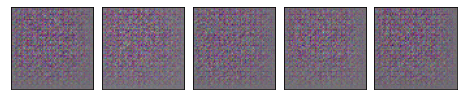

```python
samples = gen.sample(5, with_grad=False)
test.assertSequenceEqual(samples.shape, (5, *x0.shape[1:]))
test.assertIsNone(samples.grad_fn)
_ = plot.tensors_as_images(samples.cpu())

samples = gen.sample(5, with_grad=True)
test.assertSequenceEqual(samples.shape, (5, *x0.shape[1:]))
test.assertIsNotNone(samples.grad_fn)
```

### Training

Training GANs is a bit different since we need to train two models simultaneously, each with it's own separate loss function and optimizer. We'll implement the training logic as a function that handles one batch of data and updates both the discriminator and the generator based on it.

As mentioned above, GANs are considered hard to train. To get some ideas and tips you can see this [paper](https://arxiv.org/pdf/1606.03498.pdf), this list of ["GAN hacks"](https://github.com/soumith/ganhacks) or just do it the hard way :)

**TODO**:

1. Implement the `train_batch` function in the `hw4/gan.py` module.
2. Tweak the hyperparameters in the `part3_gan_hyperparams()` function within the `hw4/answers.py` module.

```python
import torch.optim as optim
from torch.utils.data import DataLoader
from hw4.answers import part3_gan_hyperparams

torch.manual_seed(42)

# Hyperparams
hp = part3_gan_hyperparams()
batch_size = hp['batch_size']
z_dim = hp['z_dim']

# Data
dl_train = DataLoader(ds_gwb, batch_size, shuffle=True)
im_size = ds_gwb[0][0].shape

# Model
dsc = gan.Discriminator(im_size).to(device)
gen = gan.Generator(z_dim, featuremap_size=4).to(device)

# Optimizer
def create_optimizer(model_params, opt_params):
    opt_params = opt_params.copy()
    optimizer_type = opt_params['type']
    opt_params.pop('type')
    return optim.__dict__[optimizer_type](model_params, **opt_params)
dsc_optimizer = create_optimizer(dsc.parameters(), hp['discriminator_optimizer'])
gen_optimizer = create_optimizer(gen.parameters(), hp['generator_optimizer'])

# Loss
def dsc_loss_fn(y_data, y_generated):
    return gan.discriminator_loss_fn(y_data, y_generated, hp['data_label'], hp['label_noise'])

def gen_loss_fn(y_generated):
    return gan.generator_loss_fn(y_generated, hp['data_label'])

# Training
checkpoint_file = 'checkpoints/gan'
checkpoint_file_final = f'{checkpoint_file}_final'
if os.path.isfile(f'{checkpoint_file}.pt'):
    os.remove(f'{checkpoint_file}.pt')

# Show hypers
print(hp)
```

```
{'batch_size': 8, 'z_dim': 256, 'data_label': 1, 'label_noise': 0.3, 'discriminator_optimizer': {'type': 'Adam', 'lr': 0.0005}, 'generator_optimizer': {'type': 'Adam', 'lr': 0.0005}}
```

**TODO**:

1. Implement the `save_checkpoint` function in the `hw4.gan` module. You can decide on your own criterion regarding whether to save a checkpoint at the end of each epoch.
2. Run the following block to train. It will sample some images from your model every few epochs so you can see the progress.
3. When you're satisfied with your results, rename the checkpoints file by adding `_final`. When you run the `main.py` script to generate your submission, the final checkpoints file will be loaded instead of running training. Note that your final submission zip will not include the `checkpoints/` folder. This is OK.

```python
import IPython.display
import tqdm
from hw4.gan import train_batch, save_checkpoint

num_epochs = 100

if os.path.isfile(f'{checkpoint_file_final}.pt'):
    print(f'*** Loading final checkpoint file {checkpoint_file_final} instead of training')
    num_epochs = 0
    gen = torch.load(f'{checkpoint_file_final}.pt', map_location=device)
    checkpoint_file = checkpoint_file_final

try:
    dsc_avg_losses, gen_avg_losses = [], []
    for epoch_idx in range(num_epochs):
        # We'll accumulate batch losses and show an average once per epoch.
        dsc_losses, gen_losses = [], []
        print(f'--- EPOCH {epoch_idx+1}/{num_epochs} ---')

        with tqdm.tqdm(total=len(dl_train.batch_sampler), file=sys.stdout) as pbar:
            for batch_idx, (x_data, _) in enumerate(dl_train):
                x_data = x_data.to(device)
                dsc_loss, gen_loss = train_batch(
                    dsc, gen,
                    dsc_loss_fn, gen_loss_fn,
                    dsc_optimizer, gen_optimizer,
                    x_data)
                dsc_losses.append(dsc_loss)
                gen_losses.append(gen_loss)
                pbar.update()

        dsc_avg_losses.append(np.mean(dsc_losses))
        gen_avg_losses.append(np.mean(gen_losses))
        print(f'Discriminator loss: {dsc_avg_losses[-1]}')
        print(f'Generator loss:     {gen_avg_losses[-1]}')

        if save_checkpoint(gen, dsc_avg_losses, gen_avg_losses, checkpoint_file):
            print(f'Saved checkpoint.')


        samples = gen.sample(5, with_grad=False)
        fig, _ = plot.tensors_as_images(samples.cpu(), figsize=(6,2))
        IPython.display.display(fig)
        plt.close(fig)
except KeyboardInterrupt as e:
    print('\n *** Training interrupted by user')
```

```
*** Loading final checkpoint file checkpoints/gan_final instead of training
```

```
*** Images Generated from best model:
```

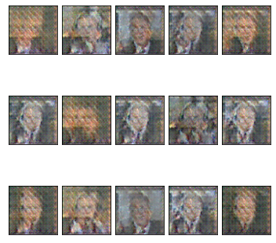

```python
# Plot images from best or last model
if os.path.isfile(f'{checkpoint_file}.pt'):
    gen = torch.load(f'{checkpoint_file}.pt', map_location=device)
print('*** Images Generated from best model:')
samples = gen.sample(n=15, with_grad=False).cpu()
fig, _ = plot.tensors_as_images(samples, nrows=3, figsize=(6,6))
```

## Questions

**TODO** Answer the following questions. Write your answers in the appropriate variables in the module `hw4/answers.py`.

```python
from cs3600.answers import display_answer
import hw4.answers
```

### Question 1

Explain in detail why during training we sometimes need to maintain gradients when sampling from the GAN, and other times we don't. When are they maintained and why? When are they discarded and why?

```python
display_answer(hw4.answers.part3_q1)
```

**Your answer:** While training the GAN model, we basically optimizing the loss functions of the generator and the discriminator. The generator is trained by generating a data point, send it to the discriminator and updating it based on the loss function. In this case, we do maintain gradients because we want to update the weights of the generator during backprop. The discriminator it trained by getting the data from the generator, classify it, and update the loss function based on the classification. In this case, we don't update the generator wights so we don't maintain the gradients.

### Question 2

1. When training a GAN to generate images, should we decide to stop training solely based on the fact that the Generator loss is below some threshold? Why or why not?
2. What does it mean if the discriminator loss remains at a constant value while the generator loss decreases?

```python
display_answer(hw4.answers.part3_q2)
```

**Your answer:**

1. No, the GAN performance depends both on the loss value of the generatot and the discriminator. Maybe the deiscriminator is easily fooled by the generator, so the generator loss in this case will decrease although it's not generating good data.

2. It means that the generator is still fooling the discriminator, without the econd one identifing it. In other words, the discriminator is failing on seperating between real data and fake data from the generator. This means that the model is failing in it's pupose to train.

### Question 3

Compare the results you got when generating images with the VAE to the GAN results. What's the main difference and what's causing it?

```python
display_answer(hw4.answers.part3_q3)
```

**Your answer:** We can see that the GAN produced more realistic and sharper images comparing to the VAE. The VAE tries to generate images based on the MSE loss comparing the input data and the generated data. This causes the bluriness of the output. It also causes the generated images be similar to each other. On the pther hand, the GAN's generator is not aware at all to the input data. All it has is the discriminator decision wheter it has done a good job in generating the images on not. By that, well designed generator and discriminator will produce better images.

$$ \newcommand{\mat}[1]{\boldsymbol {#1}} \newcommand{\mattr}[1]{\boldsymbol {#1}^\top} \newcommand{\matinv}[1]{\boldsymbol {#1}^{-1}} \newcommand{\vec}[1]{\boldsymbol {#1}} \newcommand{\vectr}[1]{\boldsymbol {#1}^\top} \newcommand{\rvar}[1]{\mathrm {#1}} \newcommand{\rvec}[1]{\boldsymbol{\mathrm{#1}}} \newcommand{\diag}{\mathop{\mathrm {diag}}} \newcommand{\set}[1]{\mathbb {#1}} \newcommand{\cset}[1]{\mathcal{#1}} \newcommand{\norm}[1]{\left\lVert#1\right\rVert} \newcommand{\pderiv}[2]{\frac{\partial #1}{\partial #2}} \newcommand{\bb}[1]{\boldsymbol{#1}} \newcommand{\E}[2][]{\mathbb{E}_{#1}\left[#2\right]} \newcommand{\ip}[3]{\left<#1,#2\right>_{#3}} \newcommand{\given}[]{\,\middle\vert\,} \newcommand{\DKL}[2]{\cset{D}_{\text{KL}}\left(#1\,\Vert\, #2\right)} \newcommand{\grad}[]{\nabla} \newcommand{\norm}[1]{\left\lVert#1\right\rVert} $$

# Part 3: Summary Questions

This section contains summary questions about various topics from the course material.

You can add your answers in new cells below the questions.

**Notes**

- Clearly mark where your answer begins, e.g. write "**Answer:**" in the beginning of your cell.
- Provide a full explanation, even if the question doesn't explicitly state so. We will reduce points for partial explanations!
- This notebook should be runnable from start to end without any errors.

### CNNs

1. Explain the meaning of the term "receptive field" in the context of CNNs.

**Answer:** The receptive field is the region of the input space that a cnn feature is affected by. Basically, the size of the kernel the cnn layer operates on defines the receptive field.

1. Explain and elaborate about three different ways to control the rate at which the receptive field grows from layer to layer. Compare them to each other in terms of how they combine input features.

**Answer**:

- Change the conv net depth- We explained above theat the kernel size of one layer controls the RF of the next layer. If we add more layers, the number of kernels the image will pass through is larger, what will cause the RF of the last layer to grow (same as for decreasing the dipth of the net).
- Add diliation- when adding diliation to the kernel, it creates a bigger kernel with the same parameters number. for example, the receptive field of a 3x3 kernel with diliation of 2 has the same RF as a regular kernel of size 5x5.
- Add stride- When adding a stride to a convolutional layer, there are more inputs which affect the output of the layer comparing to a general conv layer which changes by 1 (pixel for example) it location.
1. Imagine a CNN with three convolutional layers, defined as follows:

```python
import torch
import torch.nn as nn

cnn = nn.Sequential(
    nn.Conv2d(in_channels=3, out_channels=4, kernel_size=3, padding=1),
    nn.ReLU(),
    nn.MaxPool2d(2),
    nn.Conv2d(in_channels=4, out_channels=16, kernel_size=5, stride=2, padding=2),
    nn.ReLU(),
    nn.MaxPool2d(2),
    nn.Conv2d(in_channels=16, out_channels=32, kernel_size=7, dilation=2, padding=3),
    nn.ReLU(),
)

cnn(torch.rand(size=(1, 3, 1024, 1024), dtype=torch.float32)).shape
```

```
torch.Size([1, 32, 122, 122])
```

What is the size (spatial extent) of the receptive field of each "pixel" in the output tensor?

**Answer**:

We will use the following recusive formula to compute the receptive field- $r_o = \sum_{l=1}^{L}\left(\left({k_l-1}\right)\prod_{i=1}^{l-1}s_i\right)+1$

$=> r_0 = ((3-1)*1 + (2-1)*1*1 + (5-1)*2*1*1 + (2-1)*1*2*1*1 + (7*2-1 -1)*1*1*2*1*1) + 1 = 38$

- The number of channels between layers and padding don't affect RF.
- The diliation of the last layer causes the kernel to be of a size- 7*2-1
1. You have trained a CNN, where each layer $l$ is represented by the mapping $\vec{y}_l=f_l(\vec{x};\vec{\theta}_l)$, and $f_l(\cdot;\vec{\theta}_l)$ is a convolutional layer (not including the activation function).

   After hearing that residual networks can be made much deeper, you decide to change each layer in your network you used the following residual mapping instead $\vec{y}_l=f_l(\vec{x};\vec{\theta}_l)+\vec{x}$, and re-train.

   However, to your surprise, by visualizing the learned filters $\vec{\theta}_l$ you observe that the original network and the residual network produce completely different filters. Explain the reason for this.

**Answer** Residual networks were desined in order to solve the issue of vanishing gradients in deep convolutional networks. As the depth of the cnn increases, the gradients in the deeper layers gets smaller and smaller and can eeven get to a situation the nn can't learn at all. When using the skip connection and propagating the input to the ouput of the conv layer, we enable the gradients to flow via this skip connection during the backpropgation phase. This causes the filters to be generated completely different.

### Dropout

1. Consider the following neural network:

```python
import torch.nn as nn

p1, p2 = 0.1, 0.2
nn.Sequential(
    nn.Conv2d(in_channels=3, out_channels=4, kernel_size=3, padding=1),
    nn.ReLU(),
    nn.Dropout(p=p1),
    nn.Dropout(p=p2),
)
```

```
Sequential(
  (0): Conv2d(3, 4, kernel_size=(3, 3), stride=(1, 1), padding=(1, 1))
  (1): ReLU()
  (2): Dropout(p=0.1, inplace=False)
  (3): Dropout(p=0.2, inplace=False)
)
```

If we want to replace the two consecutive dropout layers with a single one defined as follows:

```
nn.Dropout(p=q)
```

what would the value of `q` need to be? Write an expression for `q` in terms of `p1` and `p2`.

**Answer:** The combined droput will be- $\\q = 1-(1-p1)*(1-p2)$

1. **True or false**: dropout must be placed only after the activation function.

**Answer:** False: placing the dropout before or after the activation function doesn't change any result. The dropout layer purpose is to randomly remove a portion of the neurons in the layer. It doesn't backpropagated and doesn't affect the values of the activation function if it's applied before or after it.

1. After applying dropout with a drop-probability of $p$, the activations are scaled by $1/(1-p)$. Prove that this scaling is required in order to maintain the value of each activation unchanged in expectation.

**Answer**:

The expectation of the activation after dropout layer with probability p-

$E(activation) = p*0 + (1-p)*x = (1-p)x$ //(p*0- since the value of the output gets zeroed with probability p).

By scaling the activations by 1/(1-p) we get that the expectations is- $E(activation) = (1-p)x * \frac{1}{1-p} = x$

which is the same as the expected value of a regular netwoek not using dropout.

### Losses and Activation functions

1. You're training a an image classifier that, given an image, needs to classify it as either a dog (output 0) or a hotdog (output 1). Would you train this model with an L2 loss? if so, why? if not, demonstrate with a numerical example. What would you use instead?

**Answer**:

No. MSE is not the right choice for classification problems since its doesn't produce a final set of values as the classification problem wishes to get.

In order to get better and faster results we will use the Binary Cross Erntropy loss for this problem.

** It is possible to use MSE as a loss in classification problem, but it is not the best choice.

1. After months of research into the origins of climate change, you observe the following result:

[figure not shown]

You decide to train a cutting-edge deep neural network regression model, that will predict the global temperature based on the population of pirates in `N` locations around the globe. You define your model as follows:

```python
import torch.nn as nn

N = 42  # number of known global pirate hot spots
H = 128
mlpirate = nn.Sequential(
    nn.Linear(in_features=N, out_features=H),
    nn.Sigmoid(),
    *[
        nn.Linear(in_features=H, out_features=H), nn.Sigmoid(),
    ]*24,
    nn.Linear(in_features=H, out_features=1),
)
```

While training your model you notice that the loss reaches a plateau after only a few iterations. It seems that your model is no longer training. What is the most likely cause?

1. Referring to question 2 above: A friend suggests that if you replace the `sigmoid` activations with `tanh`, it will solve your problem. Is he correct? Explain why or why not.

1. Regarding the ReLU activation, state whether the following sentences are **true or false** and explain:
   1. In a model using exclusively ReLU activations, there can be no vanishing gradients.
   2. The gradient of ReLU is linear with its input when the input is positive.
   3. ReLU can cause "dead" neurons, i.e. activations that remain at a constant value of zero.
1. **Answer**: False- the ReLU function can cause vanishing gradients, the same way as explained above for Sigmoid.
2. **Answer**: True- The ReLU function is linear on it's positive part, so when backpropagating through it we get a gradient linear to it's input.
3. **Answer**: True- When getting a negative value, ReLU outputs 0. This causes it's output neurons to be turned off.

### Optimization

1. Explain the difference between: stochastic gradient descent (SGD), mini-batch SGD and regular gradient descent (GD).

**Answer**:

SGD- During training the algorigm updated the weights after every training example (samples are chosen randomly).

Mini-batch SGD- During training the algorithm updates the weights after a given number of training examples (mini-bach number of samples).

GD- During training the algorithm updates the weights only after going through all the traning examples.

1. Regarding SGD and GD:
   1. Provide at least two reasons for why SGD is used more often in practice compared to GD.
   2. In what cases can GD not be used at all?

**Answer**:

3.

- In GD we calculate all the derivitives in on step what causes the calculation time get very slow.
- Chances to overfit in SGD are lower since we pick a single point in random at each parameters update.
1. When the dataset is too large there will not be enough memory to hold all the parameters and gradients calculation for each step.
1. You have trained a deep resnet to obtain SoTA results on ImageNet. While training using mini-batch SGD with a batch size of $B$, you noticed that your model converged to a loss value of $l_0$ within $n$ iterations (batches across all epochs) on average. Thanks to your amazing results, you secure funding for a new high-powered server with GPUs containing twice the amount of RAM. You're now considering to increase the mini-batch size from $B$ to $2B$. Would you expect the number of of iterations required to converge to $l_0$ to decrease or increase when using the new batch size? explain in detail.

**Answer**: We expect the number of iterations to decrease since at each iteration we see twice the number of examples. Therefore, the algorithm will converge to $l_0$ after ~1/2 of the iterations.

1. For each of the following statements, state whether they're **true or false** and explain why.
   1. When training a neural network with SGD, every epoch we perform an optimization step for each sample in our dataset.
   2. Gradients obtained with SGD have less variance and lead to quicker convergence compared to GD.
   3. SGD is less likely to get stuck in local minima, compared to GD.
   4. Training with SGD requires more memory than with GD.
   5. Assuming appropriate learning rates, SGD is guaranteed to converge to a local minimum, while GD is guaranteed to converge to the global minimum.
   6. Given a loss surface with a narrow ravine (high curvature in one direction): SGD with momentum will converge more quickly than Newton's method which doesn't have momentum.
1. **Answer**: True- As stated above, SGD updates the parameters for every training sample during every iteration.
2. **Answer**: False- SGD gradients tend to have bigger variance compared to the gradients of GD. Because SGD cakculates the gradient for randomly chosen training example each time it will see very different gradient values compared to GD which calculated the mean gradients of all training examples each iteration.
3. **Asnwer**: True- When updating the parameters after every training sample, the algorithm has more option go get out of local minima comparing to only one parameters update per epoch.
4. **Answer**: False- GD requires more memory since it needs to hold the data for all gradients of all training exampls in each iteration.
5. **Answer**: False- GD can converge to local minimum, while SGD can converge to global minimum. This is the more probable situation since the randomness of the SGD is more likely to get it out of local minimas compared to GD which is not random at all (GD must start from different stating point in each epoch to avoid local minima).
6. **Answer**: True- Momentum gives big weight on the previous gradient directions. So if the surface has one drection only, momentum will cause the algorithm go bigger steps towards this direction in each iteration.
1. **Bonus** (we didn't discuss this at class): We can use bi-level optimization in the context of deep learning, by embedding an optimization problem as a layer in the network. **True or false**: In order to train such a network, the inner optimization problem must be solved with a descent based method (such as SGD, LBFGS, etc). Provide a mathematical justification for your answer.
1. You have trained a neural network, where each layer $l$ is represented by the mapping $\vec{y}_l=f_l(\vec{x};\vec{\theta}_l)$ for some arbitrary parametrized functions $f_l(\cdot;\vec{\theta}_l)$. Unfortunately while trying to break the record for the world's deepest network, you discover that you are unable to train your network with more than $L$ layers.
   1. Explain the concepts of "vanishing gradients", and "exploding gradients".
   2. How can each of these problems be caused by increased depth?
   3. Provide a numerical example demonstrating each.
   4. Assuming your problem is either of these, how can you tell which of them it is without looking at the gradient tensor(s)?

**Answer**:

1. "vanishig gradients"- Happens espacially when the network is deep

### Backpropagation

1. You wish to train the following 2-layer MLP for a binary classification task: $$ \hat{y}^{(i)} =\mat{W}_2~ \varphi(\mat{W}_1 \vec{x}^{(i)}+ \vec{b}_1) + \vec{b}_2 $$ Your wish to minimize the in-sample loss function is defined as $$ L_{\mathcal{S}} = \frac{1}{N}\sum_{i=1}^{N}\ell(y^{(i)},\hat{y}^{(i)}) + \frac{\lambda}{2}\left(\norm{\mat{W}_1}_F^2 + \norm{\mat{W}_2}_F^2 \right) $$ Where the pointwise loss is binary cross-entropy: $$ \ell(y, \hat{y}) = - y \log(\hat{y}) - (1-y) \log(1-\hat{y}) $$

   Write an analytic expression for the derivative of the final loss $L_{\mathcal{S}}$ w.r.t. each of the following tensors: $\mat{W}_1$, $\mat{W}_2$, $\mat{b}_1$, $\mat{b}_2$, $\mat{x}$.
1. The derivative of a function $f(\vec{x})$ at a point $\vec{x}_0$ is $$ f'(\vec{x}_0)=\lim_{\Delta\vec{x}\to 0} \frac{f(\vec{x}_0+\Delta\vec{x})-f(\vec{x}_0)}{\Delta\vec{x}} $$
   1. Explain how this formula can be used in order to compute gradients of neural network parameters numerically, without automatic differentiation (AD).
   2. What are the drawbacks of this approach? List at least two drawbacks compared to AD.

**Answer**:

1. This formula can be used instead of calculating the gradients analitically in backpropagation. It can be used when the AD can't handle the computation overload.
2. This approach can be less accurate, since it doesn't uses chain rule as AD use to calculate complex deivatives. Also, it can be slower to compute.
1. Given the following code snippet:
   1. Write a short snippet that implements that calculates gradient of `loss` w.r.t. `W` and `b` using the approach of numerical gradients from the previous question.
   2. Calculate the same derivatives with autograd.
   3. Show, by calling `torch.allclose()` that your numerical gradient is close to autograd's gradient.

```python
import torch

N, d = 100, 5
dtype = torch.float64
X = torch.rand(N, d, dtype=dtype)
W, b = torch.rand(d, d, requires_grad=True, dtype=dtype), torch.rand(d, requires_grad=True, dtype=dtype)

def foo(W, b):
    return torch.mean(X @ W + b)

loss = foo(W, b)
print(f"{loss=}")

# TODO: Calculate gradients numerically for W and b
# grad_W =...
# grad_b =...

# TODO: Compare with autograd using torch.allclose()
# autograd_W = ...
# autograd_b = ...
# assert torch.allclose(grad_W, autograd_W)
# assert torch.allclose(grad_b, autograd_b)
```

```
loss=tensor(1.6421, dtype=torch.float64, grad_fn=<MeanBackward0>)
```

### Sequence models

1. Regarding word embeddings:
   1. Explain this term and why it's used in the context of a language model.

   **Answer:** Word embeddings is a learned representation for text where words that have the same meaning have a similar representation. In fact it's a class of techniques where individual words are represented as real-valued vectors in a predefined vector space. Each word is mapped to one vector and the vector values are learned in a way that resembles a neural network. There are different techniques for learning these representations, for example Embedding-Layer, Word2Vec and Glove. A language model is the use of statistical and probabilistic techniques to determine the probability of a given sequence of words occurring in a sentence. Language models are using in NLP applications in general and particularly ones that generate text as an output. One type of language models is the Neural Language Models, which make uses of neural networks and word embeddings.
   1. Can a language model like the sentiment analysis example from the tutorials be trained without an embedding (i.e. trained directly on sequences of tokens)? If yes, what would be the consequence for the trained model? if no, why not?

   **Answer:** Technically, language models can be trained without an embedding. Word embeddings help in capturing the semantic and syntactic contexts of different words, and therefore probably will result with lower results.
1. Considering the following snippet, explain:
   1. What does `Y` contain? why this output shape?

   **Answer** Y contain the actual vector representation of each token in the X n-dimentional tensor. Each vector length is 42000. The output shape is the input shape with the addition of the vector length as the last layer
   1. **Bonus**: How you would implement `nn.Embedding` yourself using only torch tensors.

   **Answer** At the end the nn.Embedding module is a lookup table that stores the tokens representations. Probably, I would hold a torch tensor with two dimensions, the first with the number of embeddings as indices, and the second with the actual tokens representations for each index.

```python
import torch.nn as nn

X = torch.randint(low=0, high=42, size=(5, 6, 7, 8))
embedding = nn.Embedding(num_embeddings=42, embedding_dim=42000)
Y = embedding(X)
print(f"{Y.shape=}")
```

```
Y.shape=torch.Size([5, 6, 7, 8, 42000])
```

1. Regarding truncated backpropagation through time (TBPTT) with a sequence length of S: State whether the following sentences are **true or false**, and explain.
   1. TBPTT uses a modified version of the backpropagation algorithm.

   **Answer** True. TBPTT, is a modified version of the BPTT training algorithm (which is a modified version of the backpropagation algorithm) for recurrent neural networks where the sequence is processed one timestep at a time and periodically the BPTT update is performed back for a fixed number of timesteps.
   1. To implement TBPTT we only need to limit the length of the sequence provided to the model to length S.

   **Answer** False. To implement TBPTT we shouldn't limit the length of the input sequence. The algorithm processes the sequence one timestep at a time and update periodically using the BPTT algotithm for a fixed number of timesteps. We need to define two key parameters for TBPTT:
   - k1: The number of forward-pass timesteps between updates.
   - k2: The number of timesteps to which to apply BPTT.
   1. TBPTT allows the model to learn relations between input that are at most S timesteps apart.

   **Answer** False. Because we can apply the BPTT update every k1 timesteps, we can define S (k2) to be low enough to still learn relations between different "time-batches".

### Attention

1. In tutorial 5 we learned how to use attention to perform alignment between a source and target sequence in machine translation.
   1. Explain qualitatively what the addition of the attention mechanism between the encoder and decoder does to the hidden states that the encoder and decoder each learn to generate (for their language). How are these hidden states different from the model without attention?
   2. After learning that self-attention is gaining popularity thanks to the transformer models, you decide to change the model from the tutorial: instead of the queries being equal to the decoder hidden states, you use self-attention, so that the keys, queries and values are all equal to the encoder's hidden states (with learned projections, like in the tutorial..). What influence do you expect this will have on the learned hidden states?

**Answer**:

In a regular encoder decoder mechanism the encoder encodes the input sequence to one fixed length context vector which is used by the decoder. This produces a limitaition (especialy as the input sequence gets longer) to the ability of the decoder to decode based on this fixed lenght context vector. When adding attention mechanism between the encoder and the decoder, each output vector of the decoder is based now on it's own context vector, which is affected by the output vectors of the input sequence and by **the hidden states of the decoder in of the previous step**. This is how the hidden states of the decoder areaffected by the attention mechanism.

### Unsupervised learning

1. As we have seen, a variational autoencoder's loss is comprised of a reconstruction term and a KL-divergence term. While training your VAE, you accidentally forgot to include the KL-divergence term. What would be the qualitative effect of this on:
   1. Images reconstructed by the model during training ($x\to z \to x'$)?

   **Answer** The VAE loss is comprised of both the reconstruction term that makes the encoding-decoding scheme efficient, and the KL-divergence term that can be interpreted as a regularizer which prevents the inference network from copying x into z. Therefore, if we forgot to include the KL-divergence term, our model can be led into a sub-optimal solution where the decoder ignores the inferred latent code z, and suffer from an issue known as posterior collapse where the encoder become independent of x and the inference network produces uninformative latent variables. Due that, the images reconstructed by the model during training probably will show great results.
   1. Images generated by the model ($z \to x'$)?

   **Answer** As explained above, the decoder ignores the inferred latent code z, so the generated images should suffer from bad results.
1. Regarding VAEs, state whether each of the following statements is **true or false**, and explain:
   1. The latent-space distribution generated by the model for a specific input image is $\mathcal{N}(\vec{0},\vec{I})$.

   **Answer** False. In our case we did choose the latent-space distribution to be $\mathcal{N}(\vec{0},\vec{I})$, but it surely not a must. As explained in class, for example it can be $x \sim \mathcal{N}(\mu, \Sigma)$
   1. If we feed the same image to the encoder multiple times, then decode each result, we'll get the same reconstruction.

   **Answer** True. At the end VAE forward function is sequential operations on different layers, if we didn't update any weights between the different inputs and only pass it forward we should get the same results (reconstruction).
   1. Since the real VAE loss term is intractable, what we actually minimize instead is it's upper bound, in the hope that the bound is tight.

   **Answer** False. We are maximizing the variational lower bound on the data likelihood which is the reconstructed term
1. Regarding GANs, state whether each of the following statements is **true or false**, and explain:
   1. Ideally, we want the generator's loss to be low, and the discriminator's loss to be high so that it's fooled well by the generator.

   **Answer** True. GAN's loss consist of two parts, the expected conditional log-likelihood for real and generated data, while the discriminator output the probability that the sample is real.

   $ V(D,G) = \mathbb{E}_{x \sim p(x)} \left[ \log D(x) \right] + \mathbb{E}_{z\sim q(z)} \left[\log(1 - D\left(G(z)\right)) \right] $

   The generator can't directly affect the $\log(D(x))$ term in the function, so, for the generator, minimizing the loss is equivalent to minimizing $\log(1 - D(G(z)))$. The discriminator wants to correctly distinguish real and fake samples, so we want to maximize it's loss.
   1. It's crucial to backpropagate into the generator when training the discriminator.

   **Answer** False. When training the discriminator we freeze the generator and backpropogate only the discriminator.
   1. To generate a new image, we can sample a latent-space vector from $\mathcal{N}(\vec{0},\vec{I})$.

   **Answer** True. GAN is an implicit model, means it does not try to estimate $𝑃(𝑋)$ explicitly like VAE (not even $𝑃(𝑋|𝑧)$. When we want to generate a new image we only need to use the generator and provide him with a random noise as an input, this random noise vecotr can be sampled from the described latent-space distribution.
   1. It can be beneficial for training the generator if the discriminator is trained for a few epochs first, so that it's output isn't arbitrary.

   **Answer** True. Altough studies still didn't prove it, the basic idea is correct. If you can't train a classifier to tell the difference between real and generated data even for the initial random generator output, you can't get the GAN training started.
   1. If the generator is generating plausible images and the discriminator reaches a stable state where it has 50% accuracy (for both image types), training the generator more will further improve the generated images.

   **Answer** False. In that case the discriminator is no longer contribute to the system and along with that the generator can't improve due to the bad feedback.

### Detection and Segmentation

1. What is the diffrence between IoU and Dice score? what's the diffrance between IoU and mAP? shortly explain when would you use what evaluation?

   **Answer** IoU - Intersection over Union, is the rate of overlap area over the union area. Meaning, what % of the predicted and ground-true area is covered by the prediction mask. Dice score - is 2 * the area of overlap divided by the total number of pixels in both images. The IoU and Dice are very similar and even positivly correlated. Dice counts twich the true positive while IoU counts true positives once in both the numerator and denominator.The difference comes when taking the average score over a set of inferences. In general, the IoU metric tends to penalize single instances of bad classification more than Dice score quantitatively even when they can both agree that this one instance is bad. The IoU metric tends to have a "squaring" effect on the errors relative to the Dice score. So the Dice score tends to measure something closer to average performance, while the IoU score measures something closer to the worst case performance.

   mAP - Mean average precision, when there are several classes in the segmentation problem, the mAP calculate the mean AP (average precision) among them, where AP is the integral under the Pricision-Recall curve for the relevant class.

   We would use mAP when we don't want to set specific weights on some classes. We would use IoU when we want to give more weight for larger errors and Dice otherwise.
1. regarding of YOLO and mask-r-CNN, witch one is one stage detector? describe the RPN outputs and the YOLO output, adress how the network produce the output and the shapes of each output.

   **Answer** A one-stage detector, requires only a single pass through the neural network and predicts all the bounding boxes in one go, between both, YOLO is a one stage detector. RPN outputs - Region Proposal Network takes an image of any size as input and outputs a set of rectangular object proposals each with an objectness score. YOLO output - YOLO has 24 convolutional layers followed by 2 fully connected layers. Some convolution layers use 1 × 1 reduction layers alternatively to reduce the depth of the features maps. For the last convolution layer, it outputs a tensor with shape (7, 7, 1024). The tensor is then flattened. Using 2 fully connected layers as a form of linear regression, it outputs 7×7×30 parameters and then reshapes to (7, 7, 30), i.e. 2 boundary box predictions per location.

$$ \newcommand{\mat}[1]{\boldsymbol {#1}} \newcommand{\mattr}[1]{\boldsymbol {#1}^\top} \newcommand{\matinv}[1]{\boldsymbol {#1}^{-1}} \newcommand{\vec}[1]{\boldsymbol {#1}} \newcommand{\vectr}[1]{\boldsymbol {#1}^\top} \newcommand{\rvar}[1]{\mathrm {#1}} \newcommand{\rvec}[1]{\boldsymbol{\mathrm{#1}}} \newcommand{\diag}{\mathop{\mathrm {diag}}} \newcommand{\set}[1]{\mathbb {#1}} \newcommand{\cset}[1]{\mathcal{#1}} \newcommand{\norm}[1]{\left\lVert#1\right\rVert} \newcommand{\pderiv}[2]{\frac{\partial #1}{\partial #2}} \newcommand{\bb}[1]{\boldsymbol{#1}} \newcommand{\E}[2][]{\mathbb{E}_{#1}\left[#2\right]} \newcommand{\ip}[3]{\left<#1,#2\right>_{#3}} \newcommand{\given}[]{\,\middle\vert\,} \newcommand{\DKL}[2]{\cset{D}_{\text{KL}}\left(#1\,\Vert\, #2\right)} \newcommand{\grad}[]{\nabla} $$

# Part 4: Mini-Project

In this part you'll implement a small comparative-analysis project, heavily based on the materials from the tutorials and homework.

### Guidelines

- You should implement the code which displays your results in this notebook, and add any additional code files for your implementation in the `project/` directory. You can import these files here, as we do for the homeworks.
- Running this notebook should not perform any training - load your results from some output files and display them here. The notebook must be runnable from start to end without errors.
- You must include a detailed write-up (in the notebook) of what you implemented and how.
- Explain the structure of your code and how to run it to reproduce your results.
- Explicitly state any external code you used, including built-in pytorch models and code from the course tutorials/homework.
- Analyze your numerical results, explaining **why** you got these results (not just specifying the results).
- Where relevant, place all results in a table or display them using a graph.
- Before submitting, make sure all files which are required to run this notebook are included in the generated submission zip.
- Try to keep the submission file size under 10MB. Do not include model checkpoint files, dataset files, or any other non-essentials files. Instead include your results as images/text files/pickles/etc, and load them for display in this notebook.

## Spectrally-Normalized Wasserstein GANs

One of the prevailing approaches for improving training stability for GANs is to use a technique called [Spectral Normalization](https://arxiv.org/pdf/1802.05957.pdf) to normalize the largest singular value of a weight matrix so that it equals 1. This approach is generally applied to the discriminator's weights in order to stabilize training. The resulting model is sometimes referred to as a SN-GAN. See Appendix A in the linked paper for the exact algorithm. You can also use pytorch's `spectral_norm`.

Another very common improvement to the vanilla GAN is known a [Wasserstein GAN](https://arxiv.org/pdf/1701.07875.pdf) (WGAN). It uses a simple modification to the loss function, with strong theoretical justifications based on the Wasserstein (earth-mover's) distance. See the tutorial or [here](https://developers.google.com/machine-learning/gan/loss) for a brief explanation of this loss function.

One problem with generative models for images is that it's difficult to objectively assess the quality of the resulting images. To also obtain a quantitative score for the images generated by each model, we'll use the [Inception Score](https://arxiv.org/pdf/1606.03498.pdf). This uses a pre-trained Inception CNN model on the generated images and computes a score based on the predicted probability for each class. Although not a perfect proxy for subjective quality, it's commonly used a way to compare generative models. You can use an implementation of this score that you find online, e.g. [this one](https://github.com/sbarratt/inception-score-pytorch) or implement it yourself.

You would gain a **Bonus** if you also adress [Gradient Penalty](https://arxiv.org/pdf/1704.00028.pdf), as we saw in the tutorial that it could improve the robustness of the GAN and essentially improve the results

Based on the linked papers, add Spectral Normalization and the Wassertein loss to your GAN from HW3. Compare between:

- The baseline model (vanilla GAN)
- SN-GAN (vanilla + Spectral Normalization)
- WGAN (using Wasserstein Loss)
- Optional: SN+WGAN, i.e. a combined model using both modifications.
- Bonus: WGAN+GP and SN+WGAN+GP

As a dataset, you can use [LFW](http://vis-www.cs.umass.edu/lfw/) as in HW3 or [CelebA](http://mmlab.ie.cuhk.edu.hk/projects/CelebA.html), or even choose a custom dataset (note that there's a dataloder for CelebA in `torchvision`).

Your results should include:

- Everything written in the **Guidelines** above.
- A comparative analysis between the baseline and the other models. Compare:
  - Subjective quality (show multiple generated images from each model)
  - Inception score (can use a subset of the data).
- You should show substantially improved subjective visual results with these techniques.

## Imports of essential packages

```python
# general
import unittest
import os
import sys
import pathlib
import urllib
import shutil
import re
import zipfile

import numpy as np
import matplotlib.pyplot as plt

# pytorch related
import torch
from torch.utils.data import DataLoader
import torchvision.transforms as T
from torchvision.datasets import ImageFolder

# current directory related imports
import cs3600.plot as plot
import cs3600.download
from hw4.answers import PART3_CUSTOM_DATA_URL as CUSTOM_DATA_URL

# all project's modules
from project.gan import *
from project.gan_dataloader import *
from project.gan_hyperparameters import *
from project.gan_training import *

%load_ext autoreload
%autoreload 2

test = unittest.TestCase()
plt.rcParams.update({'font.size': 12})
device = torch.device('cuda' if torch.cuda.is_available() else 'cpu')
print('Using device:', device)
```

```
Using device: cpu
```

## Notes-

- Each model was trained for 200 epochs.
- Each model output was evaluaed by the FID score.
- Source code located under- project/
- Relevant output files (FID scores & generated images without checkopoints) are located under- project/generated_data
- 'load_generated_data=**True**' was added in advance to all *Train()* calls. In order to train the models please change it to **False**.
- in case of training, must use GPU.

## Loading data into pytorch dataset

```python
ds_train = MyDataSet()
dataset = ds_train.ds_gwb
```

```
File C:\Users\alon2\.pytorch-datasets\lfw-bush.zip exists, skipping download.
Extracting C:\Users\alon2\.pytorch-datasets\lfw-bush.zip...
Extracted 531 to C:\Users\alon2\.pytorch-datasets\lfw/George_W_Bush
```

## GAN

###### Uses the same architecture from part 2

```python
print(Discriminator(in_size=[3,256,256]).to(device))
print(Generator(512).to(device))
```

```
Discriminator(
  (cnn): EncoderCNN(
    (cnn): Sequential(
      (0): Conv2d(3, 64, kernel_size=(5, 5), stride=(2, 2), padding=(2, 2))
      (1): MaxPool2d(kernel_size=3, stride=1, padding=1, dilation=1, ceil_mode=False)
      (2): BatchNorm2d(64, eps=1e-06, momentum=0.9, affine=True, track_running_stats=True)
      (3): ReLU()
      (4): Dropout2d(p=0.3, inplace=False)
      (5): Conv2d(64, 128, kernel_size=(5, 5), stride=(2, 2), padding=(2, 2))
      (6): MaxPool2d(kernel_size=3, stride=1, padding=1, dilation=1, ceil_mode=False)
      (7): BatchNorm2d(128, eps=1e-06, momentum=0.9, affine=True, track_running_stats=True)
      (8): ReLU()
      (9): Dropout2d(p=0.3, inplace=False)
      (10): Conv2d(128, 256, kernel_size=(5, 5), stride=(2, 2), padding=(2, 2))
      (11): MaxPool2d(kernel_size=3, stride=1, padding=1, dilation=1, ceil_mode=False)
      (12): BatchNorm2d(256, eps=1e-06, momentum=0.9, affine=True, track_running_stats=True)
      (13): ReLU()
      (14): Dropout2d(p=0.3, inplace=False)
      (15): Conv2d(256, 256, kernel_size=(5, 5), stride=(1, 1), padding=(2, 2))
    )
  )
  (out_layer): Linear(in_features=262144, out_features=1, bias=True)
)
Generator(
  (in_layer): Linear(in_features=512, out_features=8192, bias=False)
  (cnn): Sequential(
    (0): ConvTranspose2d(512, 512, kernel_size=(5, 5), stride=(1, 1), padding=(2, 2))
    (1): BatchNorm2d(512, eps=1e-06, momentum=0.9, affine=True, track_running_stats=True)
    (2): ReLU()
    (3): ConvTranspose2d(512, 256, kernel_size=(5, 5), stride=(2, 2), padding=(2, 2), output_padding=(1, 1))
    (4): BatchNorm2d(256, eps=1e-06, momentum=0.9, affine=True, track_running_stats=True)
    (5): ReLU()
    (6): ConvTranspose2d(256, 128, kernel_size=(5, 5), stride=(2, 2), padding=(2, 2), output_padding=(1, 1))
    (7): BatchNorm2d(128, eps=1e-06, momentum=0.9, affine=True, track_running_stats=True)
    (8): ReLU()
    (9): ConvTranspose2d(128, 64, kernel_size=(5, 5), stride=(2, 2), padding=(2, 2), output_padding=(1, 1))
    (10): BatchNorm2d(64, eps=1e-06, momentum=0.9, affine=True, track_running_stats=True)
    (11): ReLU()
    (12): ConvTranspose2d(64, 3, kernel_size=(5, 5), stride=(2, 2), padding=(2, 2), output_padding=(1, 1))
  )
)
```

#### Training

```
{'batch_size': 8, 'z_dim': 256, 'data_label': 1, 'label_noise': 0.3, 'discriminator_optimizer': {'type': 'Adam', 'lr': 0.0005}, 'generator_optimizer': {'type': 'Adam', 'lr': 0.0005}, 'n_critic': 1, 'c': 0.0}
*** Loading final checkpoint file project_checkpoints/gan_final instead of training
Best fid score is: 808.4785160203573

*** Images Generated from best model:
```

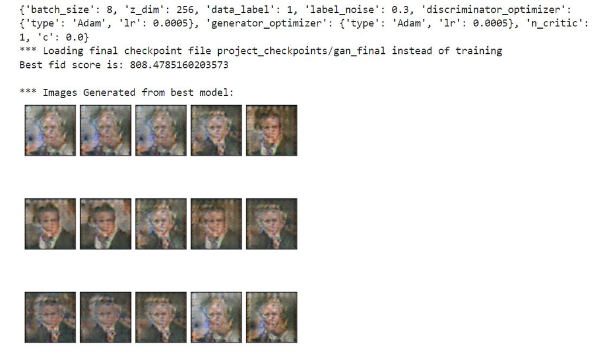

```python
GANTrainer = Train(name='gan',dataset=dataset, device=device, load_generated_data=True).train(200)
```

## GAN with spectral normalized weights

###### The weights of the discriminator's CNNs are normalized using 'spectral_norm' implementation from torch.nn.utils

```python
print(SNDiscriminator(in_size=[3,256,256], out_channels=256).to(device))
print(Generator(512).to(device))
```

```
SNDiscriminator(
  (cnn): Sequential(
    (0): Conv2d(3, 64, kernel_size=(5, 5), stride=(2, 2), padding=(2, 2))
    (1): MaxPool2d(kernel_size=3, stride=1, padding=1, dilation=1, ceil_mode=False)
    (2): BatchNorm2d(64, eps=1e-06, momentum=0.9, affine=True, track_running_stats=True)
    (3): ReLU()
    (4): Dropout2d(p=0.3, inplace=False)
    (5): Conv2d(64, 128, kernel_size=(5, 5), stride=(2, 2), padding=(2, 2))
    (6): MaxPool2d(kernel_size=3, stride=1, padding=1, dilation=1, ceil_mode=False)
    (7): BatchNorm2d(128, eps=1e-06, momentum=0.9, affine=True, track_running_stats=True)
    (8): ReLU()
    (9): Dropout2d(p=0.3, inplace=False)
    (10): Conv2d(128, 256, kernel_size=(5, 5), stride=(2, 2), padding=(2, 2))
    (11): MaxPool2d(kernel_size=3, stride=1, padding=1, dilation=1, ceil_mode=False)
    (12): BatchNorm2d(256, eps=1e-06, momentum=0.9, affine=True, track_running_stats=True)
    (13): ReLU()
    (14): Dropout2d(p=0.3, inplace=False)
    (15): Conv2d(256, 256, kernel_size=(5, 5), stride=(1, 1), padding=(2, 2))
  )
  (out_layer): Linear(in_features=262144, out_features=1, bias=True)
)
Generator(
  (in_layer): Linear(in_features=512, out_features=8192, bias=False)
  (cnn): Sequential(
    (0): ConvTranspose2d(512, 512, kernel_size=(5, 5), stride=(1, 1), padding=(2, 2))
    (1): BatchNorm2d(512, eps=1e-06, momentum=0.9, affine=True, track_running_stats=True)
    (2): ReLU()
    (3): ConvTranspose2d(512, 256, kernel_size=(5, 5), stride=(2, 2), padding=(2, 2), output_padding=(1, 1))
    (4): BatchNorm2d(256, eps=1e-06, momentum=0.9, affine=True, track_running_stats=True)
    (5): ReLU()
    (6): ConvTranspose2d(256, 128, kernel_size=(5, 5), stride=(2, 2), padding=(2, 2), output_padding=(1, 1))
    (7): BatchNorm2d(128, eps=1e-06, momentum=0.9, affine=True, track_running_stats=True)
    (8): ReLU()
    (9): ConvTranspose2d(128, 64, kernel_size=(5, 5), stride=(2, 2), padding=(2, 2), output_padding=(1, 1))
    (10): BatchNorm2d(64, eps=1e-06, momentum=0.9, affine=True, track_running_stats=True)
    (11): ReLU()
    (12): ConvTranspose2d(64, 3, kernel_size=(5, 5), stride=(2, 2), padding=(2, 2), output_padding=(1, 1))
  )
)
```

#### Training

```
{'batch_size': 8, 'z_dim': 256, 'data_label': 1, 'label_noise': 0.3, 'discriminator_optimizer': {'type': 'Adam', 'lr': 0.0005}, 'generator_optimizer': {'type': 'Adam', 'lr': 0.0005}, 'n_critic': 1, 'c': 0.0}
*** Loading final checkpoint file project_checkpoints/sngan_final instead of training
Best fid score is: 395.3704723645333

*** Images Generated from best model:
```

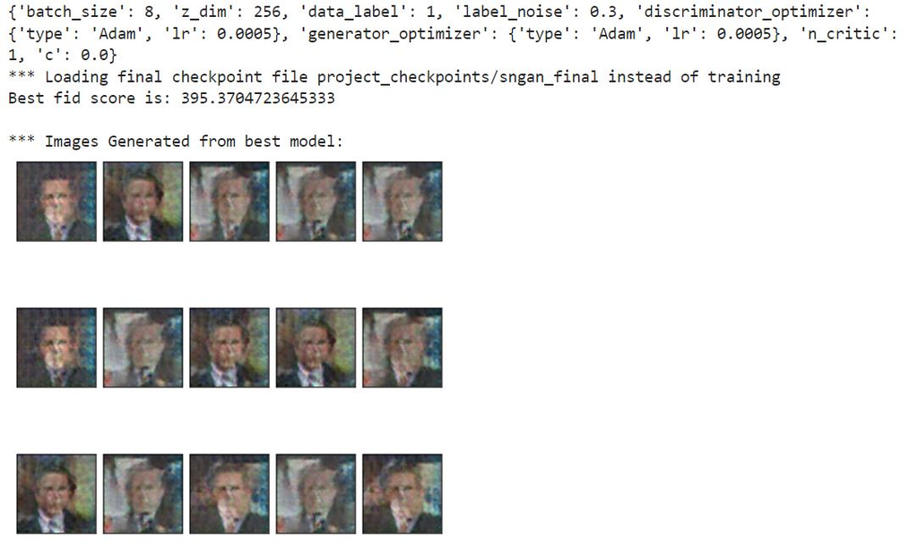

```python
SNGANTrainer = Train(name='sngan',dataset=dataset, device=device, load_generated_data=True).train(200)
```

## Wasserstein GAN

###### Using different architectures for both generator and discriminator

```python
print(WganDiscriminator(in_size=[3,256,256]).to(device))
print(WganGenerator(512).to(device))
```

```
WganDiscriminator(
  (conv): Sequential(
    (0): Conv2d(3, 64, kernel_size=(4, 4), stride=(2, 2), padding=(1, 1), bias=False)
    (1): ReLU()
    (2): Conv2d(64, 128, kernel_size=(4, 4), stride=(2, 2), padding=(1, 1), bias=False)
    (3): BatchNorm2d(128, eps=1e-05, momentum=0.1, affine=True, track_running_stats=True)
    (4): ReLU()
    (5): Conv2d(128, 256, kernel_size=(4, 4), stride=(2, 2), padding=(1, 1), bias=False)
    (6): BatchNorm2d(256, eps=1e-05, momentum=0.1, affine=True, track_running_stats=True)
    (7): ReLU()
    (8): Conv2d(256, 512, kernel_size=(4, 4), stride=(2, 2), padding=(1, 1), bias=False)
    (9): BatchNorm2d(512, eps=1e-05, momentum=0.1, affine=True, track_running_stats=True)
    (10): ReLU()
    (11): Conv2d(512, 1, kernel_size=(4, 4), stride=(1, 1), bias=False)
  )
)
WganGenerator(
  (decoder): Sequential(
    (0): ConvTranspose2d(512, 512, kernel_size=(4, 4), stride=(1, 1), bias=False)
    (1): BatchNorm2d(512, eps=1e-05, momentum=0.1, affine=True, track_running_stats=True)
    (2): ReLU()
    (3): ConvTranspose2d(512, 256, kernel_size=(4, 4), stride=(2, 2), padding=(1, 1), bias=False)
    (4): BatchNorm2d(256, eps=1e-05, momentum=0.1, affine=True, track_running_stats=True)
    (5): ReLU()
    (6): ConvTranspose2d(256, 128, kernel_size=(4, 4), stride=(2, 2), padding=(1, 1), bias=False)
    (7): BatchNorm2d(128, eps=1e-05, momentum=0.1, affine=True, track_running_stats=True)
    (8): ReLU()
    (9): ConvTranspose2d(128, 64, kernel_size=(4, 4), stride=(2, 2), padding=(1, 1), bias=False)
    (10): BatchNorm2d(64, eps=1e-05, momentum=0.1, affine=True, track_running_stats=True)
    (11): ReLU()
    (12): ConvTranspose2d(64, 3, kernel_size=(4, 4), stride=(2, 2), padding=(1, 1), bias=False)
  )
)
```

#### Training

```
{'batch_size': 8, 'z_dim': 256, 'data_label': 1, 'label_noise': 0.3, 'discriminator_optimizer': {'type': 'RMSprop', 'lr': 0.0005}, 'generator_optimizer': {'type': 'RMSprop', 'lr': 0.0005}, 'n_critic': 1, 'c': 0.01}
*** Loading final checkpoint file project_checkpoints/wgan_final instead of training
Best fid score is: 27.87501741786278

*** Images Generated from best model:
```

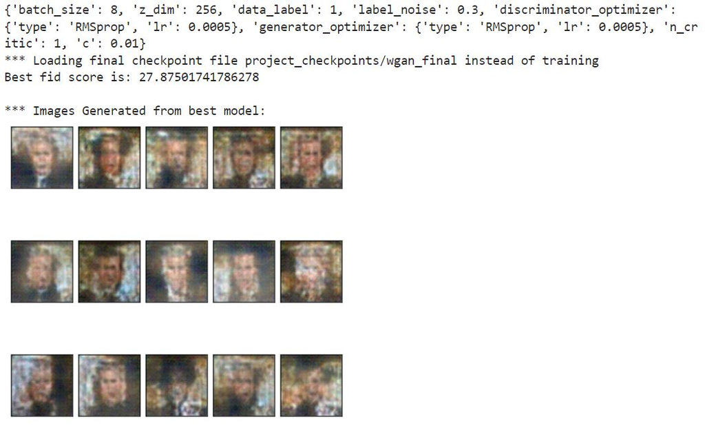

```python
WGANTrainer = Train(name='wgan',dataset=dataset, device=device, load_generated_data=True).train(200)
```

## Wasserstein GAN with spectral normalizd weights

###### A combination of the Wasserstein GAN from above and the discriminator's CNNs normalized using 'spectral_norm' implementation from torch.nn.utils

#### Training

```
{'batch_size': 8, 'z_dim': 256, 'data_label': 1, 'label_noise': 0.3, 'discriminator_optimizer': {'type': 'RMSprop', 'lr': 0.0002}, 'generator_optimizer': {'type': 'RMSprop', 'lr': 0.0002}, 'n_critic': 1, 'c': 0.01}
*** Loading final checkpoint file project_checkpoints/snwgan_final instead of training
Best fid score is: 74.56782702982547

*** Images Generated from best model:
```

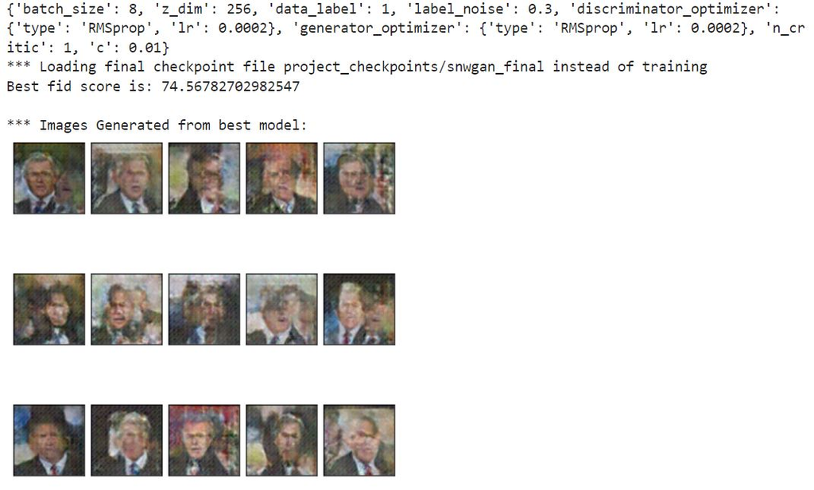

```python
SNWGANTrainer = Train(name='snwgan',dataset=dataset, device=device, load_generated_data=True).train(200)
```

# Conclusion

- Visualized results-
  1. We can clearly see an improvement as we move from a basic GAN or wasserstein gan implementations to the same architectures but with spectral normalized weights.
  2. Basic GAN compared with Wasserstein GAN- The second got us smoother but less distorted images.
  3. When looking at the Spectral normalized Wasserstein GAN compared to the basic GAN we notice a big improvement of the results- generated images are much clearer and less distorted. Small objects looks more sharp and clear (the tie for example).
- FID score-

  The FID score-
  1. Basic GAN - 808
  2. Spectral normalized GAN - 395
  3. Wasserstein GAN - 28
  4. ** Spectral normalized Wasserstein GAN - 74

** The FID score of the Spectral normalized Wasserstein GAN was varied in each training phase (best results we saw was 37)- Unlike the other architectires which gave more stable results.